# Like clockwork? A longitudinal test of an epigenetic clock in wild European losters (Homarus gammarus)

Erik Sandertun Røed

2024-05-14

# Code: Age estimation

## Data availability statement

The data required to knit this rmd file are included in the repository, except that a) the data at `METHYLATION_PATH` may be requested from Marie Saitou (marie.saitou@nmbu.no) or Louise Chavarie (louise.chavarie@nmbu.no), and b) the data at `FAIRFIELD_DATA_PATH` should be archived by or available from the authors of:

Fairfield, E.A. et al. (2021) “Ageing European lobsters (Homarus gammarus) using DNA methylation of evolutionarily conserved ribosomal DNA,” Evolutionary Applications, 14(9), 2305–2318. Available at: https://doi.org/10.1111/eva.13296.

## Step 0: Setup

### Random seed

I set the random seed to a set value so that models are trained consistently:

```r
#         N M B U
set.seed(14130220)
```

### Dependencies

I use the following CRAN packages in this document:

```r
# For RMarkdown report
library(knitr)
library(kableExtra)

# For data wrangling
library(readxl)
library(dplyr)
library(tidyr)
library(lubridate)
library(magrittr)
library(stringr)

# For visualisation
library(ggplot2)
library(ggh4x)
library(patchwork)
library(ggsignif)
library(ggnewscale)
library(ggvenn)

# For colours
library(viridis) # Used via ggplot viridis functions
library(RColorBrewer)

# For (more or less formal) analyses and model training
library(lmerTest)
library(MuMIn)
library(caret)
library(rsample)
```

### Universal plotting definitions

#### Colours

```r
CAP_COLOUR <- RColorBrewer::brewer.pal(n = 6, "Dark2")[5]
RECAP_COLOUR <- RColorBrewer::brewer.pal(n = 6, "Dark2")[6]
FEMALE_COLOUR <- RColorBrewer::brewer.pal(n = 3, "Set2")[2]
MALE_COLOUR <- RColorBrewer::brewer.pal(n = 3, "Set2")[3]
MODEL_COLOURS <- RColorBrewer::brewer.pal(4, "Set1")
MODEL_TEST_TRAIN_COLOURS <- RColorBrewer::brewer.pal(4, "Paired")
```

#### Universal plot themes

```r
ggtheme_scatter <- ggplot2::theme(
  panel.border = ggplot2::element_rect(colour = "black", fill = NA),
  panel.grid = ggplot2::element_blank()
)

ggtheme_heatmap <- ggplot2::theme(
  axis.text.x = ggplot2::element_text(hjust = 0, size = 7),
  axis.ticks = ggplot2::element_blank(),
  axis.title.y = ggplot2::element_text(vjust = 3),
  legend.background = ggplot2::element_rect(
    colour = "black",
    fill = "#ebebeb",
    linewidth = 0.25
  ),
  legend.justification = c(0, 1),
  panel.border = ggplot2::element_rect(
    colour = "black",
    fill = NA
  ),
  panel.grid = ggplot2::element_blank()
)
```

#### Locus labels

We have sequencing data for 442 loci across the 18S, ITS1 - ITS2, and 28S regions. I define below the index of the first locus in each region so we can label their position. With this I produce a vector of labels for all 442 loci.

```r
PLOT_LOCUS_LABELS <- rep(x = "", length.out = 442) %>%
  replace(
    list   = c(1,     116,    137,    186),
    values = c("18S", "ITS1", "ITS2", "28S")
  )
```

## Step 1: Data import and wrangling

### Dataset definitions

First, define the (relative) dataset paths within the R project:

```r
LOBSTER_PATH <- "../data/20240330_lobage_lobsters_48ind_96dna.xlsx"
METHYLATION_PATH <- "../data/20240313_lobage_methylation_48ind_96dna.xlsx"
```

### Reading in Fairfield data

Read in the coefficients from the Fairfield *et al.* (2021) paper (the corresponding author kindly confirmed these values).

```r
FAIRFIELD_ELASTICNET_CpG <- readRDS("../data/FAIRFIELD_ELASTICNET_CpG.rds")
```

Also define the relative path to their original methylation dataset (for later):

```r
FAIRFIELD_DATA_PATH <- "../data/FAIRFIELD_lobster_data_for_dryad.xls"
```

### Load and wrangle lobster data

#### Lobster data

I load the lobster dataset in its original wider format, where one row corresponds to one lobster. Make the necessary “type declarations”:

```r
lobsters <- LOBSTER_PATH %>%
  readxl::read_xlsx(sheet = "LobsterData", na = "NA") %>%
  dplyr::mutate(LobsterID = factor(LobsterID, levels = LobsterID)) %>%
  dplyr::mutate(Sex = factor(Sex, levels = c("F", "M"))) %>%
  dplyr::mutate(ZoneID = factor(ZoneID, levels = c("M", "S", "NE"))) %>%
  dplyr::mutate(
    CaptureIntervalBins = factor(
      CaptureIntervalBins, levels = rev(unique(CaptureIntervalBins))
    )
  )
```

I also add new columns for the capture interval in months, the mean length of capture and recapture, the “seasonality”, i.e. “Dec-Dec”, “Sep-Sep”, “Sep-Dec”, or “Dec-Sep” (coded as “1212”, “99”, “912”, and “129”), and “egg class” i.e. whether a female went from having eggs to not having them, vice versa, had both times, or neither (+-, -+, ++, –):

```r
DAYS_IN_MONTH <- 30.5

lobsters %<>%
  dplyr::mutate(
    CaptureIntervalMonths = round(
      CaptureIntervalDays / DAYS_IN_MONTH,
      digits = 1
    ),
    .after = CaptureIntervalBins
  ) %>%
  dplyr::mutate(
    MeanLengthCM = (CaptureLengthCM + RecaptureLengthCM) / 2,
    .after = RecaptureLengthCM
  ) %>%
  dplyr::mutate(
    Seasonality = factor(
      paste0(
        lubridate::month(CaptureDate),
        lubridate::month(RecaptureDate)
      ),
      levels = c("99", "912", "1212", "129")
    ),
    .after = RecaptureDate
  ) %>%
  mutate(
    EggsClass = factor(
      ifelse(
        Sex == "M", NA,
        paste0(
          ifelse(CaptureEggs, "+", "-"),
          ifelse(RecaptureEggs, "+", "-")
        )
      ),
      levels = c("--", "-+", "+-", "++")
    ),
    .after = RecaptureEggs,
  )
```

TABLE 1: N = 10 first lobsters.

| LobsterID | ZoneID | Sex | CaptureDate | RecaptureDate | Seasonality | CaptureIntervalDays | CaptureIntervalBins | CaptureIntervalMonths | CaptureEggs | RecaptureEggs | EggsClass | CaptureLengthCM | RecaptureLengthCM | MeanLengthCM | GrowthCM | CaptureSampleNumber | RecaptureSampleNumber |
| --- | --- | --- | --- | --- | --- | --- | --- | --- | --- | --- | --- | --- | --- | --- | --- | --- | --- |
| C0361 | M | F | 2020-09-21 | 2023-09-06 | 99 | 1080 | 36 mo. | 35.4 | FALSE | TRUE | -+ | 25.0 | 27.0 | 26.00 | 2.0 | 48 | 96 |
| C0879 | NE | F | 2021-09-16 | 2023-12-03 | 912 | 808 | 27 mo. | 26.5 | FALSE | FALSE | – | 27.0 | 29.8 | 28.40 | 2.8 | 11 | 49 |
| 00833 | M | F | 2021-09-16 | 2023-12-02 | 912 | 807 | 27 mo. | 26.5 | FALSE | TRUE | -+ | 29.0 | 30.0 | 29.50 | 1.0 | 12 | 50 |
| 00834 | M | M | 2021-09-16 | 2023-12-02 | 912 | 807 | 27 mo. | 26.5 | NA | NA | NA | 32.5 | 33.0 | 32.75 | 0.5 | 13 | 51 |
| C0816 | M | M | 2021-09-17 | 2023-12-03 | 912 | 807 | 27 mo. | 26.5 | NA | NA | NA | 26.5 | 31.0 | 28.75 | 4.5 | 14 | 52 |
| 00793 | M | F | 2021-12-06 | 2023-12-06 | 1212 | 730 | 24 mo. | 23.9 | FALSE | FALSE | – | 19.0 | 23.0 | 21.00 | 4.0 | 15 | 53 |
| C0671 | M | F | 2021-12-05 | 2023-12-05 | 1212 | 730 | 24 mo. | 23.9 | FALSE | FALSE | – | 25.0 | 26.0 | 25.50 | 1.0 | 16 | 54 |
| 01039 | M | F | 2021-12-05 | 2023-12-03 | 1212 | 728 | 24 mo. | 23.9 | FALSE | FALSE | – | 29.0 | 30.5 | 29.75 | 1.5 | 17 | 65 |
| 00653 | S | M | 2021-12-08 | 2023-12-06 | 1212 | 728 | 24 mo. | 23.9 | NA | NA | NA | 25.0 | 31.0 | 28.00 | 6.0 | 5 | 62 |
| C0621 | M | F | 2021-12-05 | 2023-12-02 | 1212 | 727 | 24 mo. | 23.8 | FALSE | FALSE | – | 24.5 | 26.5 | 25.50 | 2.0 | 18 | 66 |

#### Sample data

For some of my purposes, it is easier to consider the data in a longer format, where each row corresponds to one *sample* rather than one *lobster*. Pivot like so:

```r
lobster_samples <- lobsters %>%
  dplyr::select(-GrowthCM, -MeanLengthCM, -Seasonality, -EggsClass) %>%
  dplyr::mutate(MonthsPassed = CaptureIntervalMonths, .after = Sex) %>%
  dplyr::select(-contains("Interval")) %>%
  tidyr::pivot_longer(
    cols = contains("apture"),
    names_pattern = "(.*apture)(.*)$",
    names_to = c("Encounter", "Measurement"),
    # All values must be same type, I convert them back below
    values_transform = as.character,
    names_transform = as.factor
  ) %>%
  tidyr::pivot_wider(
    # Pivot each measurement out to a column
    names_from = "Measurement",
    values_from = "value"
  ) %>%
  dplyr::mutate(
    MonthsPassed = ifelse(Encounter == "Capture", 0, MonthsPassed)
  ) %>%
  dplyr::mutate(LengthCM = as.numeric(LengthCM)) %>%
  dplyr::mutate(Date = as.Date.character(Date)) %>%
  dplyr::mutate(SampleNumber = as.numeric(SampleNumber)) %>%
  dplyr::mutate(Eggs = as.logical(Eggs))
```

I also add columns where I separate out the year and month the sample was taken, so I can use these in a nested random effect in linear mixed models:

```r
lobster_samples %<>%
  mutate(Year = lubridate::year(Date), .after = Date) %>%
  mutate(Month = lubridate::month(Date), .after = Year) %>%
  mutate(Year = as.factor(Year)) %>%
  mutate(Month = as.factor(Month))
```

TABLE 2: N = 10 first lobster samples.

| LobsterID | ZoneID | Sex | MonthsPassed | Encounter | Date | Year | Month | Eggs | LengthCM | SampleNumber |
| --- | --- | --- | --- | --- | --- | --- | --- | --- | --- | --- |
| C0361 | M | F | 0.0 | Capture | 2020-09-21 | 2020 | 9 | FALSE | 25.0 | 48 |
| C0361 | M | F | 35.4 | Recapture | 2023-09-06 | 2023 | 9 | TRUE | 27.0 | 96 |
| C0879 | NE | F | 0.0 | Capture | 2021-09-16 | 2021 | 9 | FALSE | 27.0 | 11 |
| C0879 | NE | F | 26.5 | Recapture | 2023-12-03 | 2023 | 12 | FALSE | 29.8 | 49 |
| 00833 | M | F | 0.0 | Capture | 2021-09-16 | 2021 | 9 | FALSE | 29.0 | 12 |
| 00833 | M | F | 26.5 | Recapture | 2023-12-02 | 2023 | 12 | TRUE | 30.0 | 50 |
| 00834 | M | M | 0.0 | Capture | 2021-09-16 | 2021 | 9 | NA | 32.5 | 13 |
| 00834 | M | M | 26.5 | Recapture | 2023-12-02 | 2023 | 12 | NA | 33.0 | 51 |
| C0816 | M | M | 0.0 | Capture | 2021-09-17 | 2021 | 9 | NA | 26.5 | 14 |
| C0816 | M | M | 26.5 | Recapture | 2023-12-03 | 2023 | 12 | NA | 31.0 | 52 |

### Load and wrangle methylation data

#### Methylation (raw beta values)

Next, I wrangle the methylation data so that each sample number corresponds to one row, with all the methylation data in the columns following the sample number column.

```r
COLUMN_PREFIX <- "S"
COLUMN_SUFFIX_METHYLATION <- ".meth_ratio"

sample_methylation <- METHYLATION_PATH %>%
  readxl::read_xlsx(sheet = "meth_ratio") %>%
  tidyr::unite(chrom, start, col = "CpG", sep = "_") %>%
  dplyr::select(-end) %>% # Don't need end position of CpGs (always +1)
  tidyr::pivot_longer(
    cols = - CpG,
    names_to = "SampleNumber",
    values_to = "Methylation",
    names_pattern = paste0(COLUMN_PREFIX, "(.*)", COLUMN_SUFFIX_METHYLATION),
    names_transform = as.numeric
  ) %>%
  tidyr::pivot_wider(
    names_from = CpG,
    values_from = "Methylation"
  ) %>%
  # Add the prefix "CpG_" to each column name
  dplyr::rename_with(.fn = ~ paste0("CpG_", .x), .cols = dplyr::contains("ITS"))
```

TABLE 3: Methylation ratios in N = 5 first lobster samples.

| SampleNumber | CpG_18S_ITS1_141 | CpG_18S_ITS1_154 | CpG_18S_ITS1_178 | CpG_18S_ITS1_185 | CpG_18S_ITS1_190 | CpG_18S_ITS1_222 | CpG_18S_ITS1_231 | CpG_18S_ITS1_235 | CpG_18S_ITS1_242 | CpG_18S_ITS1_247 | CpG_18S_ITS1_250 | CpG_18S_ITS1_253 | CpG_18S_ITS1_285 | CpG_18S_ITS1_300 | CpG_18S_ITS1_318 | CpG_18S_ITS1_325 | CpG_18S_ITS1_340 | CpG_18S_ITS1_346 | CpG_18S_ITS1_366 | CpG_18S_ITS1_397 | CpG_18S_ITS1_414 | CpG_18S_ITS1_419 | CpG_18S_ITS1_433 | CpG_18S_ITS1_443 | CpG_18S_ITS1_459 | CpG_18S_ITS1_467 | CpG_18S_ITS1_473 | CpG_18S_ITS1_501 | CpG_18S_ITS1_538 | … |
| --- | --- | --- | --- | --- | --- | --- | --- | --- | --- | --- | --- | --- | --- | --- | --- | --- | --- | --- | --- | --- | --- | --- | --- | --- | --- | --- | --- | --- | --- | --- |
| 1 | 0.3204164 | 0.3983247 | 0.2794457 | 0.5812879 | 0.7749856 | 0.5747285 | 0.8523883 | 0.7669601 | 0.8801382 | 0.7101674 | 0.3504834 | 0.7850242 | 0.1667529 | 0.5320800 | 0.3087144 | 0.3553562 | 0.0444751 | 0.1444387 | 0.0906897 | 0.3379032 | 0.5314516 | 0.6588710 | 0.2146893 | 0.5088853 | 0.7104839 | 0.7330645 | 0.6483871 | 0.4629032 | 0.2568807 | … |
| 2 | 0.3203639 | 0.3664101 | 0.2493706 | 0.5614943 | 0.7595468 | 0.5525155 | 0.8617213 | 0.7673392 | 0.8860851 | 0.7122769 | 0.3480220 | 0.7985773 | 0.1655564 | 0.5254237 | 0.3093694 | 0.3400324 | 0.0343834 | 0.1254060 | 0.0680346 | 0.3658751 | 0.5229008 | 0.6496479 | 0.1977119 | 0.4810795 | 0.7362863 | 0.7677419 | 0.6388970 | 0.4313380 | 0.2439502 | … |
| 3 | 0.2743530 | 0.3510762 | 0.2399012 | 0.5191162 | 0.7248693 | 0.5393683 | 0.8441158 | 0.7363412 | 0.8696994 | 0.6628163 | 0.3730935 | 0.7697322 | 0.1377246 | 0.4749692 | 0.2901975 | 0.3262787 | 0.0376794 | 0.1326269 | 0.0858150 | 0.3678466 | 0.5275893 | 0.6691263 | 0.2072019 | 0.4787485 | 0.6991438 | 0.7276483 | 0.6365782 | 0.4332940 | 0.2184288 | … |
| 4 | 0.3579111 | 0.4308004 | 0.2987215 | 0.5845411 | 0.7930175 | 0.5950448 | 0.8628361 | 0.7889628 | 0.8876582 | 0.7020490 | 0.4284507 | 0.8090765 | 0.1789896 | 0.5769596 | 0.3863612 | 0.4268215 | 0.0562058 | 0.1912979 | 0.1161637 | 0.4338728 | 0.6087685 | 0.7178771 | 0.2421111 | 0.5541597 | 0.7583799 | 0.7837989 | 0.6991620 | 0.5064210 | 0.3008306 | … |
| 5 | 0.3016494 | 0.3825503 | 0.2530053 | 0.5439038 | 0.7329887 | 0.5575468 | 0.8394038 | 0.7609667 | 0.8666667 | 0.6967690 | 0.4031267 | 0.7728324 | 0.1517494 | 0.5260051 | 0.3356476 | 0.3713373 | 0.0445312 | 0.1550196 | 0.1016733 | 0.3951307 | 0.5453530 | 0.6768647 | 0.2237606 | 0.5035746 | 0.7185615 | 0.7462020 | 0.6466905 | 0.4438240 | 0.2721005 | … |

#### Coverage

I similarly load the coverage data for each locus:

```r
COLUMN_SUFFIX_COVERAGE <- ".total_count"

sample_coverage <- METHYLATION_PATH %>%
  readxl::read_xlsx(sheet = "total_count") %>%
  tidyr::unite(chrom, start, col = "CpG", sep = "_") %>%
  dplyr::select(-end) %>%
  tidyr::pivot_longer(
    cols = - CpG,
    names_to = "SampleNumber",
    values_to = "Methylation",
    names_pattern = paste0(COLUMN_PREFIX, "(.*)", COLUMN_SUFFIX_COVERAGE),
    names_transform = as.numeric
  ) %>%
  tidyr::pivot_wider(
    names_from = CpG,
    values_from = "Methylation"
  ) %>%
  dplyr::rename_with(.fn = ~ paste0("CpG_", .x), .cols = dplyr::contains("ITS"))
```

TABLE 4: CpG sequencing coverage in N = 5 first lobsters.

| SampleNumber | CpG_18S_ITS1_141 | CpG_18S_ITS1_154 | CpG_18S_ITS1_178 | CpG_18S_ITS1_185 | CpG_18S_ITS1_190 | CpG_18S_ITS1_222 | CpG_18S_ITS1_231 | CpG_18S_ITS1_235 | CpG_18S_ITS1_242 | CpG_18S_ITS1_247 | CpG_18S_ITS1_250 | CpG_18S_ITS1_253 | CpG_18S_ITS1_285 | CpG_18S_ITS1_300 | CpG_18S_ITS1_318 | CpG_18S_ITS1_325 | CpG_18S_ITS1_340 | CpG_18S_ITS1_346 | CpG_18S_ITS1_366 | CpG_18S_ITS1_397 | CpG_18S_ITS1_414 | CpG_18S_ITS1_419 | CpG_18S_ITS1_433 | CpG_18S_ITS1_443 | CpG_18S_ITS1_459 | CpG_18S_ITS1_467 | CpG_18S_ITS1_473 | CpG_18S_ITS1_501 | CpG_18S_ITS1_538 | … |
| --- | --- | --- | --- | --- | --- | --- | --- | --- | --- | --- | --- | --- | --- | --- | --- | --- | --- | --- | --- | --- | --- | --- | --- | --- | --- | --- | --- | --- | --- | --- |
| 1 | 3458 | 3462 | 3464 | 3463 | 3462 | 5801 | 5799 | 5793 | 5790 | 5793 | 5792 | 5796 | 5799 | 5798 | 5795 | 5797 | 5801 | 5781 | 5800 | 1240 | 1240 | 1240 | 1239 | 1238 | 1240 | 1240 | 1240 | 1240 | 2507 | … |
| 2 | 7145 | 7145 | 7150 | 7147 | 7149 | 11111 | 11108 | 11102 | 11096 | 11094 | 11097 | 11106 | 11108 | 11092 | 11100 | 11096 | 11110 | 11084 | 11112 | 3411 | 3406 | 3408 | 3409 | 3409 | 3409 | 3410 | 3409 | 3408 | 5620 | … |
| 3 | 6878 | 6876 | 6882 | 6879 | 6884 | 11367 | 11361 | 11348 | 11343 | 11341 | 11343 | 11352 | 11356 | 11346 | 11344 | 11340 | 11359 | 11325 | 11350 | 3390 | 3389 | 3388 | 3388 | 3388 | 3387 | 3389 | 3390 | 3388 | 5741 | … |
| 4 | 6415 | 6409 | 6414 | 6417 | 6416 | 9485 | 9485 | 9477 | 9480 | 9468 | 9469 | 9475 | 9481 | 9479 | 9473 | 9470 | 9483 | 9446 | 9478 | 3584 | 3581 | 3580 | 3581 | 3582 | 3580 | 3580 | 3580 | 3582 | 5538 | … |
| 5 | 7154 | 7152 | 7154 | 7152 | 7157 | 12555 | 12547 | 12538 | 12525 | 12535 | 12537 | 12537 | 12547 | 12536 | 12531 | 12525 | 12553 | 12521 | 12550 | 4477 | 4476 | 4478 | 4478 | 4476 | 4477 | 4476 | 4472 | 4477 | 6527 | … |

#### Longer datasets

Then, I pivot both to longer versions for heatmapping. Note that I ensure the loci are factored in ascending order so they can be easily plotted in order.

```r
loci_in_order <- sample_coverage %>%
  dplyr::select(-SampleNumber) %>%
  colnames()

sample_methylation_long <- sample_methylation %>%
  tidyr::pivot_longer(
    cols = -SampleNumber,
    names_to = "Locus",
    values_to = "Methylation"
  ) %>%
  dplyr::mutate(Locus = factor(Locus, levels = loci_in_order))

sample_methylation_long <- sample_coverage %>%
  tidyr::pivot_longer(
    cols = -SampleNumber,
    names_to = "Locus",
    values_to = "Coverage"
  ) %>%
  dplyr::mutate(Locus = factor(Locus, levels = loci_in_order)) %>%
  dplyr::left_join(sample_methylation_long, .)
```

#### Methylation to M-values

The M value is statistically more sound than the regular beta values, but biologically less intuitive … this function describes the relationship between the beta value and M:

```r
convert_beta_to_m <- function(beta)
{
  m <- log2(beta / (1 - beta))
  return(m)
}
```

Adapted from Du et al. (2010) BMC Bionformatics.

I calculate the M-values for all the methylation frequencies (betas):

```r
sample_methylation_long %<>%
  dplyr::mutate(M = convert_beta_to_m(Methylation), .after = Methylation)

sample_methylation_mvalues <- sample_methylation_long %>%
  dplyr::select(-Methylation, -Coverage) %>%
  tidyr::pivot_wider(
    id_cols = SampleNumber,
    names_from = Locus,
    values_from = M
  )
```

TABLE 5: Long methylation data (first ten rows)

| SampleNumber | Locus | Methylation | M | Coverage |
| --- | --- | --- | --- | --- |
| 1 | CpG_18S_ITS1_141 | 0.3204164 | -1.0847029 | 3458 |
| 1 | CpG_18S_ITS1_154 | 0.3983247 | -0.5950404 | 3462 |
| 1 | CpG_18S_ITS1_178 | 0.2794457 | -1.3665390 | 3464 |
| 1 | CpG_18S_ITS1_185 | 0.5812879 | 0.4732943 | 3463 |
| 1 | CpG_18S_ITS1_190 | 0.7749856 | 1.7841518 | 3462 |
| 1 | CpG_18S_ITS1_222 | 0.5747285 | 0.4344964 | 5801 |
| 1 | CpG_18S_ITS1_231 | 0.8523883 | 2.5297042 | 5799 |
| 1 | CpG_18S_ITS1_235 | 0.7669601 | 1.7185747 | 5793 |
| 1 | CpG_18S_ITS1_242 | 0.8801382 | 2.8763577 | 5790 |
| 1 | CpG_18S_ITS1_247 | 0.7101674 | 1.2929396 | 5793 |

## Step 2: Explore methylation data

### Raw methylation data

#### Sequencing coverage

First, we plot the sequencing coverage:

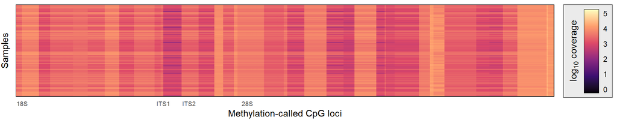

```r
plot_sequencing_coverage <- sample_methylation_long %>%
  ggplot2::ggplot(
    ggplot2::aes(
      x = Locus,
      y = SampleNumber,
      fill = log10(Coverage)
    )
  ) +
  ggplot2::geom_tile() +
  ggplot2::xlab("Methylation-called CpG loci") +
  ggplot2::scale_x_discrete(expand = c(0, 0), labels = PLOT_LOCUS_LABELS) +
  ggplot2::ylab("Samples") +
  ggplot2::scale_y_discrete(expand = c(0, 0)) +
  ggplot2::scale_fill_viridis_c(
    option = "A",
    limits = c(-0.25, 5.25), # Slightly extended range for tick justification
    breaks = seq(0, 5),
    guide = ggplot2::guide_colorbar(
      title = expression(log["10"]*" coverage"),
      display = "raster",
      ticks.colour = NA,
      frame.colour = "black",
      frame.linewidth = 0.25,
      title.position = "left",
      title.theme = ggplot2::element_text(angle = 90, hjust = 0.5),
      barheight = 6.8
    )
  ) +
  ggtheme_heatmap
```

Then we extract a useful stat, the minimum coverage at any locus in any sample:

```r
sample_coverage %>% dplyr::select(dplyr::contains("CpG")) %>% min()
```

```
## [1] 109
```

… and the mean:

```r
sample_coverage %>% dplyr::select(dplyr::contains("CpG")) %>%
  as.matrix() %>%
  mean()
```

```
## [1] 3803.796
```

#### Methylation ratios

I produce a heatmap of methylation betas too, which I will show below…

```r
plot_sample_methylation <- sample_methylation_long %>%
  ggplot2::ggplot(
    ggplot2::aes(
      x = Locus,
      y = SampleNumber,
      fill = Methylation
    )
  ) +
  ggplot2::geom_tile() +
  ggplot2::xlab("Methylation-called CpG loci") +
  ggplot2::scale_x_discrete(
    position = "top",
    expand = c(0, 0),
    labels = PLOT_LOCUS_LABELS
  ) +
  ggplot2::ylab("Samples") +
  ggplot2::scale_y_discrete(expand = c(0, 0)) +
  ggplot2::scale_fill_viridis_c(
    option = "D",
    limits = c(-0.05, 1.05), # Slightly extended range for tick justification
    breaks = seq(0, 1, by = 1),
    guide = ggplot2::guide_colorbar(
      title = expression("Methylation ( "*beta*" )"),
      display = "raster",
      ticks.colour = NA,
      frame.colour = "black",
      frame.linewidth = 0.25,
      title.position = "left",
      title.theme = ggplot2::element_text(angle = 90, hjust = 0.5),
      barheight = 13.1
    )
  ) +
  ggtheme_heatmap
```

Then I similarly get some useful stats from the methylation data:

```r
sample_methylation %>% dplyr::select(dplyr::contains("CpG")) %>% min()
```

```
## [1] 0.003229279
```

```r
sample_methylation %>% dplyr::select(dplyr::contains("CpG")) %>% max()
```

```
## [1] 0.9151652
```

```r
sample_methylation_mvalues %>% dplyr::select(dplyr::contains("CpG")) %>% min()
```

```
## [1] -8.269906
```

```r
sample_methylation_mvalues %>% dplyr::select(dplyr::contains("CpG")) %>% max()
```

```
## [1] 3.431303
```

#### Beta and M

Here I show the distribution of Beta and M values (which are the two different representations of the methylation level):

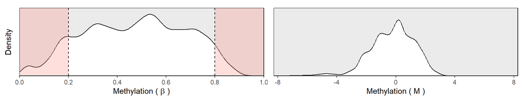

```r
beta_distribution <- sample_methylation_long %>%
  ggplot2::ggplot(aes(x = Methylation)) +
  ggplot2::scale_y_continuous(name = "Density", expand = c(0, 0)) +
  ggplot2::scale_x_continuous(
    name = expression("Methylation ( "*beta*" )"),
    limits = ggh4x::center_limits(0.5),
    breaks = seq(0, 1, 0.2),
    expand = c(0, 0)
  ) +
  ggplot2::geom_density(fill = "white") +
  ggplot2::annotate(
    "rect",
    xmin = 0, xmax = 0.2, ymin = 0, ymax = 2,
    alpha = 0.25,
    fill = "salmon"
  ) +
  ggplot2::annotate(
    "rect",
    xmin = 0.8, xmax = 1.0, ymin = 0, ymax = 2,
    alpha = 0.25,
    fill = "salmon"
  ) +
  ggplot2::geom_vline(xintercept = 0.2, lty = 2) +
  ggplot2::geom_vline(xintercept = 0.8, lty = 2) +
  theme(
    axis.ticks.y = element_blank(),
    axis.text.y = element_blank(),
    axis.title.y = element_text(vjust = 3)
  ) +
  ggtheme_scatter

mvalue_distribution <- sample_methylation_long %>%
  ggplot2::ggplot(aes(x = M)) +
  ggplot2::scale_y_continuous(name = "Density", expand = c(0, 0, 0.05, 0.05)) +
  ggplot2::scale_x_continuous(
    limits = center_limits(0),
    name = expression("Methylation ( "*M*" )"),
    expand = c(0, 0)
  ) +
  ggplot2::geom_density(fill = "white") +
  theme(
    axis.ticks.y = element_blank(),
    axis.text.y = element_blank(),
    axis.title.y = element_blank()
  ) +
  ggtheme_scatter

beta_distribution | mvalue_distribution
```

#### Beta and M methylation figure

I combine the data on methylation and the conversion from beta to M in a figure:

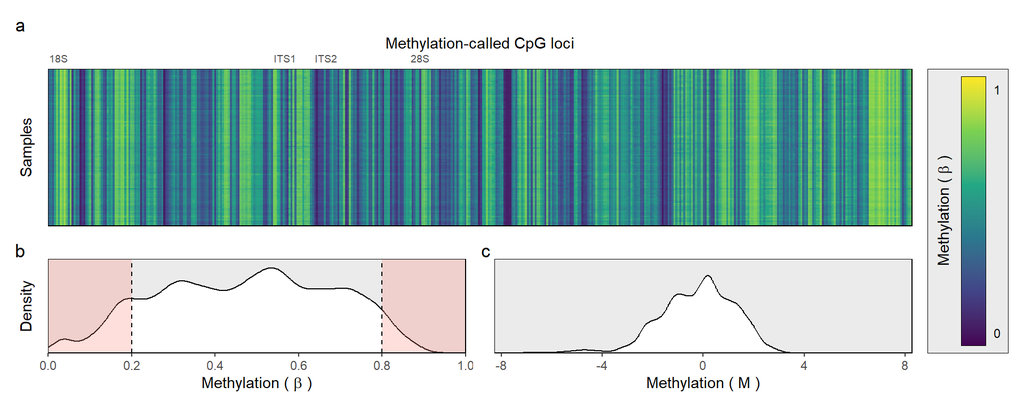

```r
plot_methylation_data <- plot_sample_methylation +
  (beta_distribution | mvalue_distribution) +
  plot_layout(heights = c(2.5, 1.5), guides = "collect") +
  plot_annotation(tag_levels = "a")
```

### Change in average methylation

I can test if the overall (i.e. average) methylation of the different lobsters is associated with time and any of the covariates: length, sex, season, and eggs for females. Specifically, I will compare the samples, taking into account which lobster they came from.

#### Calculating average methylation

To do so, I first need to calculate the average methylation (beta and M) for each sample.

```r
lobster_samples %<>%
  dplyr::left_join(sample_methylation) %>%
  dplyr::mutate(
    MeanBetaMethylation = rowMeans(
      dplyr::select(., dplyr::contains("CpG"))
    )
  ) %>%
  dplyr::select(-contains("CpG")) %>%
  dplyr::left_join(sample_methylation_mvalues) %>%
  dplyr::mutate(
    MeanMValueMethylation = rowMeans(
      dplyr::select(., dplyr::contains("CpG"))
    )
  ) %>%
  dplyr::select(-contains("CpG"))
```

Some useful stats:

```r
lobster_samples %>%
  dplyr::filter(Encounter == "Capture") %>%
  dplyr::reframe(
    MinMeanBeta = min(MeanBetaMethylation),
    MaxMeanBeta = max(MeanBetaMethylation),
    MeanMeanBeta = mean(MeanBetaMethylation),
    SDMeanBeta = sd(MeanBetaMethylation),
    MinMeanM = min(MeanMValueMethylation),
    MaxMeanM = max(MeanMValueMethylation),
    MeanMeanM = mean(MeanMValueMethylation),
    SDMeanM = sd(MeanMValueMethylation)
    )
```

```
## # A tibble: 1 × 8
##   MinMeanBeta MaxMeanBeta MeanMeanBeta SDMeanBeta MinMeanM MaxMeanM MeanMeanM
##         <dbl>       <dbl>        <dbl>      <dbl>    <dbl>    <dbl>     <dbl>
## 1       0.443       0.518        0.471     0.0162   -0.425   0.0917    -0.238
## # ℹ 1 more variable: SDMeanM <dbl>
```

```r
lobster_samples %>%
  dplyr::filter(Encounter == "Recapture") %>%
  dplyr::reframe(
    MinMeanBeta = min(MeanBetaMethylation),
    MaxMeanBeta = max(MeanBetaMethylation),
    MeanMeanBeta = mean(MeanBetaMethylation),
    SDMeanBeta = sd(MeanBetaMethylation),
    MinMeanM = min(MeanMValueMethylation),
    MaxMeanM = max(MeanMValueMethylation),
    MeanMeanM = mean(MeanMValueMethylation),
    SDMeanM = sd(MeanMValueMethylation)
    )
```

```
## # A tibble: 1 × 8
##   MinMeanBeta MaxMeanBeta MeanMeanBeta SDMeanBeta MinMeanM MaxMeanM MeanMeanM
##         <dbl>       <dbl>        <dbl>      <dbl>    <dbl>    <dbl>     <dbl>
## 1       0.441       0.517        0.477     0.0175   -0.448   0.0807    -0.202
## # ℹ 1 more variable: SDMeanM <dbl>
```

#### Statistical analysis

Then we can use a linear mixed model with `LobsterID` as a random effect for the sample dataset to see if average methylation changes with time and any of the covariates we selected samples for (i.e. sex and length). I also ask whether including the nested Year/Month random effect is meaningful. Note that I use M values for stats because that is more statistically sound:

```r
average_mvalue_lme1 <- lobster_samples %>%
  lmerTest::lmer(
    data = .,
    MeanMValueMethylation ~ MonthsPassed + LengthCM + Sex +
      (1 | LobsterID)
  )
average_mvalue_lme2 <- lobster_samples %>%
  lmerTest::lmer(
    data = .,
    MeanMValueMethylation ~ MonthsPassed + LengthCM * Sex +
      (1 | LobsterID)
  )
average_mvalue_lme3 <- lobster_samples %>%
  lmerTest::lmer(
    data = .,
    MeanMValueMethylation ~ MonthsPassed + LengthCM +
      (1 | LobsterID)
  )
average_mvalue_lme4 <- lobster_samples %>%
  lmerTest::lmer(
    data = .,
    MeanMValueMethylation ~ MonthsPassed + Sex +
      (1 | LobsterID)
  )
average_mvalue_lme5 <- lobster_samples %>%
  lmerTest::lmer(
    data = .,
    MeanMValueMethylation ~ MonthsPassed +
      (1 | LobsterID)
  )
average_mvalue_lme6 <- lobster_samples %>%
  lmerTest::lmer(
    data = .,
    MeanMValueMethylation ~ MonthsPassed +
      (1 | LobsterID) + (1 | Year/Month)
  )
```

```
## boundary (singular) fit: see help('isSingular')
```

Comparing the models with AIC, we can see that the simplest alternative has the lowest AIC… As for the singular effects, we would have followed the guidance of Barr et al. 2013 (see `?isSingular`) if `average_mvalue_lme6` were best. We note that that random effect is singular and exclude it (this is the case also if added to the other model versions).

```r
MuMIn::AICc(
  average_mvalue_lme1,
  average_mvalue_lme2,
  average_mvalue_lme3,
  average_mvalue_lme4,
  average_mvalue_lme5,
  average_mvalue_lme6
) %>% arrange(AICc)
```

```
##                     df      AICc
## average_mvalue_lme5  4 -152.0142
## average_mvalue_lme6  6 -147.5100
## average_mvalue_lme4  5 -145.1327
## average_mvalue_lme3  5 -142.1644
## average_mvalue_lme1  6 -135.1383
## average_mvalue_lme2  7 -124.5898
```

I would include `Eggs`, but I need a model that actually includes both males and females. So, I will stick to the best model for both sexes:

```r
average_mvalue_lme5 %T>% anova() %>% summary()
```

```
## Linear mixed model fit by REML. t-tests use Satterthwaite's method [
## lmerModLmerTest]
## Formula: MeanMValueMethylation ~ MonthsPassed + (1 | LobsterID)
##    Data: .
##
## REML criterion at convergence: -160.5
##
## Scaled residuals:
##      Min       1Q   Median       3Q      Max
## -1.70485 -0.51550  0.03811  0.49935  1.64628
##
## Random effects:
##  Groups    Name        Variance Std.Dev.
##  LobsterID (Intercept) 0.010179 0.10089
##  Residual              0.003523 0.05936
## Number of obs: 96, groups:  LobsterID, 48
##
## Fixed effects:
##                Estimate Std. Error         df t value Pr(>|t|)
## (Intercept)  -0.2378566  0.0168102 59.4042779 -14.150  < 2e-16 ***
## MonthsPassed  0.0018125  0.0005897 47.9717503   3.074  0.00348 **
## ---
## Signif. codes:  0 '***' 0.001 '**' 0.01 '*' 0.05 '.' 0.1 ' ' 1
##
## Correlation of Fixed Effects:
##             (Intr)
## MonthsPassd -0.346
```

For visualisation later, I expand a grid of predictions from this model:

```r
mean_mvalue_plot_lme_predictions <- lobster_samples %>%
  dplyr::select(LobsterID, Sex, MonthsPassed, LengthCM)

mean_mvalue_plot_lme_predictions$MeanMValueMethylation <- predict(
  average_mvalue_lme5, mean_mvalue_plot_lme_predictions
)
```

#### Visualisation

I make a figure to show the differences in methylation between capture and recapture, taking into account the months passed since first capture where sensible (as that is what the best model does).

For visualisation in a heatmap, I first calculate the difference in beta between capture and recapture. I use betas for the heatmap because the biological interpretation is more obvious. This also goes for the methylation heatmap I produced above! For analyses, I calculate the difference in M, too.

```r
methylation_matrix_capture <- lobster_samples %>%
  dplyr::left_join(sample_methylation) %>%
  dplyr::filter(Encounter == "Capture") %>%
  dplyr::select(contains("CpG")) %>%
  as.matrix()

methylation_matrix_recapture <- lobster_samples %>%
  dplyr::left_join(sample_methylation) %>%
  dplyr::filter(Encounter == "Recapture") %>%
  dplyr::select(contains("CpG")) %>%
  as.matrix()

lobster_methylation_delta <- methylation_matrix_recapture %>%
  magrittr::subtract(methylation_matrix_capture) %>%
  as.data.frame() %>%
  cbind(LobsterID = lobsters$LobsterID, .)

methylation_matrix_capture_mvalues <- lobster_samples %>%
  dplyr::left_join(sample_methylation_mvalues) %>%
  dplyr::filter(Encounter == "Capture") %>%
  dplyr::select(contains("CpG")) %>%
  as.matrix()

methylation_matrix_recapture_mvalues <- lobster_samples %>%
  dplyr::left_join(sample_methylation_mvalues) %>%
  dplyr::filter(Encounter == "Recapture") %>%
  dplyr::select(contains("CpG")) %>%
  as.matrix()

lobster_methylation_delta_mvalues <- methylation_matrix_recapture_mvalues %>%
  magrittr::subtract(methylation_matrix_capture_mvalues) %>%
  as.data.frame() %>%
  cbind(LobsterID = lobsters$LobsterID, .)
```

For the thesis article, the lobsters that most increase and decrease in methylation:

```r
methylation_most_increased_decreased <- lobster_samples %>%
  tidyr::pivot_wider(
    id_cols = LobsterID,
    names_from = Encounter,
    values_from = c(MeanMValueMethylation, MeanBetaMethylation)
  ) %>%
  dplyr::mutate(
    DeltaM = MeanMValueMethylation_Recapture - MeanMValueMethylation_Capture
  ) %>%
  dplyr::mutate(
    DeltaBeta = MeanBetaMethylation_Recapture - MeanBetaMethylation_Capture
  ) %>%
  dplyr::filter(DeltaM == max(DeltaM) | DeltaM == min(DeltaM)) %>%
  dplyr::select(LobsterID, dplyr::contains("Delta")) %T>%
  print()
```

```
## # A tibble: 2 × 3
##   LobsterID DeltaM DeltaBeta
##   <fct>      <dbl>     <dbl>
## 1 C0361      0.228    0.0340
## 2 C0126     -0.135   -0.0194
```

```r
# How many loci increased
methylation_most_increased_decreased %>%
  dplyr::left_join(lobster_methylation_delta_mvalues) %>%
  dplyr::select(contains("CpG")) %>%
  dplyr::mutate(across(contains("CpG"), ~{.x > 0})) %>%
  rowSums() %>%
  print()
```

```
## [1] 369  38
```

```r
# How many loci decreased
methylation_most_increased_decreased %>%
  dplyr::left_join(lobster_methylation_delta_mvalues) %>%
  dplyr::select(contains("CpG")) %>%
  dplyr::mutate(across(contains("CpG"), ~{.x < 0})) %>%
  rowSums() %>%
  print()
```

```
## [1]  73 404
```

I want to order the lobsters by ascending length in the plots below, so I produce a factor of the lobsters in that order:

```r
lobsters_factored_by_ascending_mean_length <- lobsters %>%
  dplyr::arrange(MeanLengthCM) %>%
  dplyr::mutate(LobsterID = factor(LobsterID, levels = LobsterID)) %>%
  magrittr::use_series(LobsterID)
```

I can now produce a figure. First the mean methylation as beta and M. For the M-value plot I show the results of the LME model, too, which was trained on M values.

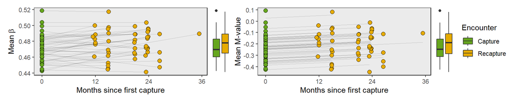

```r
plot_mean_methylation_betas <- lobster_samples %>%
  ggplot(
    aes(
      x = MonthsPassed,
      fill = Encounter,
      y = MeanBetaMethylation
    )
  ) +
  geom_line(mapping = aes(group = LobsterID), alpha = 0.1) +
  geom_point(show.legend = FALSE, pch = 21, size = 2.5) +
  scale_fill_manual(values = c(CAP_COLOUR, RECAP_COLOUR)) +
  scale_x_continuous(
    name = "Months since first capture",
    breaks = seq(from = 0, to = 36, by = 12)
  ) +
  scale_y_continuous(name = expression("Mean "*beta)) +
  ggtheme_scatter

plot_mean_methylation_mvalues <- lobster_samples %>%
  ggplot(
    aes(
      x = MonthsPassed,
      y = MeanMValueMethylation
    )
  ) +
  geom_line(
    data = mean_mvalue_plot_lme_predictions,
    mapping = aes(group = LobsterID),
    alpha = 0.1
  ) +
  geom_point(
    mapping = aes(fill = Encounter),
    show.legend = FALSE,
    pch = 21,
    size = 2.5
  ) +
  scale_fill_manual(values = c(CAP_COLOUR, RECAP_COLOUR)) +
  scale_x_continuous(
    name = "Months since first capture",
    breaks = seq(from = 0, to = 36, by = 12)
  ) +
  scale_y_continuous(name = "Mean M-value") +
  ggtheme_scatter

plot_mean_methylation_betas_boxplots <- lobster_samples %>%
  ggplot(
    aes(
      x = Encounter,
      fill = Encounter,
      y = MeanBetaMethylation
    )
  ) +
  geom_boxplot() +
  scale_fill_manual(values = c(CAP_COLOUR, RECAP_COLOUR)) +
  theme_void()

plot_mean_methylation_mvalues_boxplots <- lobster_samples %>%
  ggplot(
    aes(
      x = Encounter,
      fill = Encounter,
      y = MeanMValueMethylation
    )
  ) +
  geom_boxplot() +
  scale_fill_manual(values = c(CAP_COLOUR, RECAP_COLOUR)) +
  theme_void()

(plot_mean_methylation_betas | plot_mean_methylation_betas_boxplots |
  plot_mean_methylation_mvalues | plot_mean_methylation_mvalues_boxplots) +
  plot_layout(widths = c(4.5, 0.5, 4.5, 0.5), guides = "collect")
```

Then a heatmap of the differences in beta per locus from capture to recapture:

```r
plot_differential_methylation_heatmap <- lobsters %>%
  # Sort lobsters by descending length
  dplyr::mutate(
    LobsterID = factor(
      LobsterID,
      levels = levels(lobsters_factored_by_ascending_mean_length)
    )
  ) %>%
  left_join(lobster_methylation_delta) %>%
  # Pivot methylation differences longer for plotting
  tidyr::pivot_longer(
    cols = dplyr::contains("ITS"),
    names_to = "Locus",
    values_to = "MethylationDifference"
  ) %>%
  # Ensure loci are plotted in order
  dplyr::mutate(Locus = factor(Locus, levels = loci_in_order)) %>%
  # Plot
  ggplot2::ggplot(
    ggplot2::aes(
      y = Locus,
      x = LobsterID,
      fill = MethylationDifference
    )
  ) +
  ggplot2::geom_tile() +
  ggplot2::ylab("Methylation-called CpG loci") +
  ggplot2::scale_y_discrete(
    expand = c(0, 0),
    labels = vapply( # Add an arrow to the region labels
      PLOT_LOCUS_LABELS,
      function(a) {
        ifelse(a == "", "", paste(a, "\u2191"))
      },
      character(1)
    ) %>% unname()
  ) +
  ggplot2::scale_x_discrete(expand = c(0,0), position = "top") +
  ggplot2::xlab("Lobsters grouped by capture interval and sex (N = 48)") +
  ggplot2::scale_fill_distiller(
    palette = "RdBu",
    type = "div",
    limits = ggh4x::center_limits(),
    breaks = seq(-0.1, 0.1, by = 0.1),
    guide = ggplot2::guide_colorbar(
      title = expression(Delta*" in "*beta*" at recapture"),
      display = "raster",
      ticks.colour = NA,
      frame.colour = "black",
      frame.linewidth = 0.25,
      title.position = "left",
      title.theme = ggplot2::element_text(angle = 90, hjust = 0.5)
    )
  ) +
  ggh4x::facet_nested(
    cols = c(
      ggplot2::vars(CaptureIntervalBins),
      ggplot2::vars(Sex)
    ),
    scales = "free_x",
    space = "free_x",
    labeller = ggplot2::labeller(
      CaptureIntervalBins = c(
        `12 mo.` = "12 months",
        `15 mo.` = "15 months",
        `21 mo.` = "21 months",
        `24 mo.` = "24 months",
        `27 mo.` = "27 mo.",
        `36 mo.` = "*"
      ),
      Sex = c(
        `F` = "\u2640",
        `M` = "\u2642"
      )
    )
  ) +
  ggplot2::theme(
    axis.text.x.top = ggplot2::element_blank(),
    axis.title.x.top = ggplot2::element_text(
      vjust = 2,
      margin = margin(t = 10, b = 5)
    ),
    # So arrows in the region labels roughly begin at first CpG:
    axis.text.y.left = element_text(vjust = -0.4),
    panel.spacing.x = ggplot2::unit(0, "lines"),
    strip.background = ggplot2::element_rect(
      fill = "#ebebeb",
      colour = "black"
    )
  ) +
  ggtheme_heatmap
```

I add a number of “legend plots” that give information about the lobsters. These will help parse the information in the final figure, so I only show them there.

```r
ggtheme_legendplot <- ggplot2::theme(
    axis.title = ggplot2::element_blank(),
    axis.ticks = ggplot2::element_blank(),
    axis.text.x = ggplot2::element_blank(),
    axis.text.y = ggplot2::element_text(size = 9),
    legend.background = ggplot2::element_rect(
      fill = "#ebebeb",
      colour = "black",
      linewidth = 0.25
    ),
    panel.border = ggplot2::element_rect(fill = NA, colour = "black"),
    panel.spacing.x = ggplot2::unit(0, "lines"),
    plot.title = ggplot2::element_text(
      size = 9,
      hjust = 0
    ),
    strip.background = ggplot2::element_blank(),
    strip.text = ggplot2::element_blank()
  )

plot_differential_methylation_season <- lobsters %>%
  # Sort lobsters by descending length
  dplyr::mutate(
    LobsterID = factor(
      LobsterID,
      levels = levels(lobsters_factored_by_ascending_mean_length)
    )
  ) %>%
  # Pivot capture vs. recapture longer for season
  tidyr::pivot_longer(
    cols = c(CaptureDate, RecaptureDate),
    names_to = "Encounter",
    values_to = "Season"
  ) %>%
  dplyr::mutate(Month = lubridate::month(Season)) %>%
  dplyr::mutate(Month = ifelse(Month == "9", "Sep", "Dec")) %>%
  ggplot2::ggplot(
    ggplot2::aes(
      y = Encounter,
      x = LobsterID,
      fill = Month
    )
  ) +
  ggplot2::geom_tile() +
  ggplot2::scale_fill_manual(
    values = c("#1f78b4", "#a6cee3"), # From RColorBrewer "Paired" palette
    breaks = c("Dec", "Sep"),
    guide = ggplot2::guide_legend(
      title = "Month",
      position = "right",
      direction = "vertical",
      override.aes = ggplot2::aes(colour = "black")
    )
  ) +
  ggplot2::scale_y_discrete(expand = c(0,0), labels = c("Cap.", "Rec.")) +
  ggplot2::scale_x_discrete(expand = c(0, 0)) +
  ggh4x::facet_nested(
    cols = c(
      ggplot2::vars(CaptureIntervalBins),
      ggplot2::vars(Sex)
    ),
    scales = "free_x",
    space = "free_x"
  ) +
  ggtheme_legendplot

plot_differential_methylation_eggs <- lobsters %>%
  # Sort lobsters by descending length
  dplyr::mutate(
    LobsterID = factor(
      LobsterID,
      levels = levels(lobsters_factored_by_ascending_mean_length)
    )
  ) %>%
  # Pivot capture vs. recapture longer for eggs
  tidyr::pivot_longer(
    cols = c(CaptureEggs, RecaptureEggs),
    names_to = "Encounter",
    values_to = "Eggs"
  ) %>%
  ggplot2::ggplot(
    ggplot2::aes(
      y = Encounter,
      x = LobsterID,
      fill = Eggs
    )
  ) +
  ggplot2::geom_tile() +
  ggplot2::scale_fill_manual(
    values = c("#ff7f00", "#fdbf6f"), # From RColorBrewer "Paired" palette
    na.value = "#ebebeb",
    breaks = c("TRUE", "FALSE", NA),
    labels = c("Yes", "No", "\u2642"),
    guide = ggplot2::guide_legend(
      title = "Eggs",
      position = "right",
      direction = "vertical",
      override.aes = ggplot2::aes(colour = "black")
    )
  ) +
  ggplot2::scale_y_discrete(expand = c(0,0), labels = c("Cap.", "Rec.")) +
  ggplot2::scale_x_discrete(expand = c(0, 0)) +
  ggh4x::facet_nested(
    cols = c(
      ggplot2::vars(CaptureIntervalBins),
      ggplot2::vars(Sex)
    ),
    scales = "free_x",
    space = "free_x"
  ) +
  ggtheme_legendplot

plot_differential_methylation_length <- lobsters %>%
  # Sort lobsters by descending length
  dplyr::mutate(
    LobsterID = factor(
      LobsterID,
      levels = levels(lobsters_factored_by_ascending_mean_length)
    )
  ) %>%
  # Pivot capture vs. recapture longer for length
  tidyr::pivot_longer(
    cols = c(CaptureLengthCM, RecaptureLengthCM),
    names_to = "Encounter",
    values_to = "LengthCM"
  ) %>%
  ggplot2::ggplot(
    ggplot2::aes(
      y = Encounter,
      x = LobsterID,
      fill = LengthCM
    )
  ) +
  ggplot2::geom_tile() +
  ggplot2::scale_fill_distiller(
    palette = "Purples",
    guide = ggplot2::guide_colorbar(
      title = "Total length (cm)",
      display = "raster",
      direction = "vertical",
      title.position = "left",
      ticks.colour = NA,
      frame.colour = "black",
      frame.linewidth = 0.25,
      title.theme = ggplot2::element_text(angle = 90, hjust = 0.5),
    )
  ) +
  ggplot2::scale_y_discrete(expand = c(0,0), labels = c("Cap.", "Rec.")) +
  ggplot2::scale_x_discrete(expand = c(0, 0)) +
  ggh4x::facet_nested(
    cols = c(
      ggplot2::vars(CaptureIntervalBins),
      ggplot2::vars(Sex)
    ),
    scales = "free_x",
    space = "free_x"
  ) +
  ggtheme_legendplot
```

Then finally I patchwork this together:

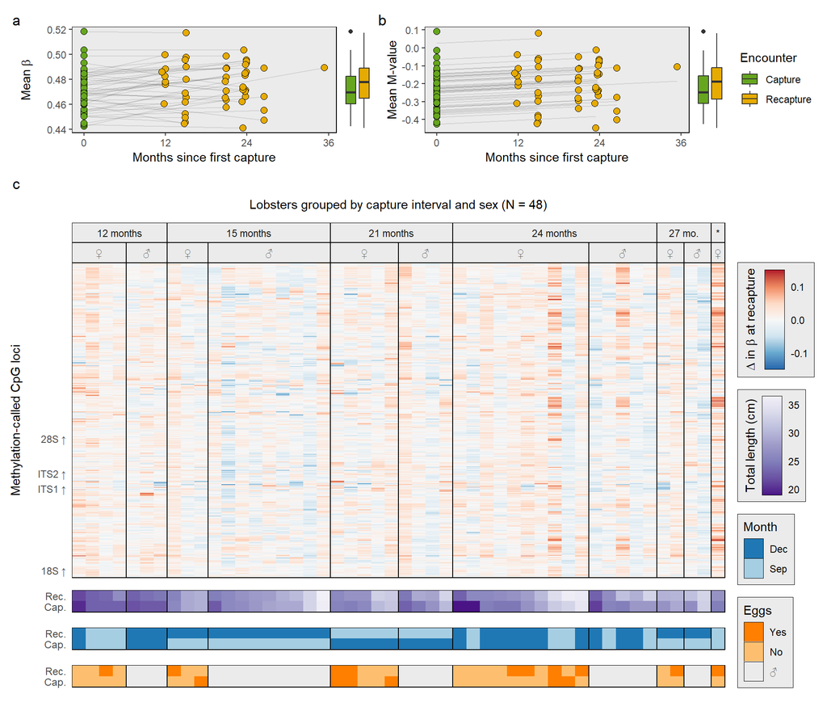

```r
plot_differential_methylation <- (
  (
    plot_mean_methylation_betas |
      (
        plot_mean_methylation_betas_boxplots + plot_layout(tag_level = "new")
      ) |
      plot_mean_methylation_mvalues |
      (
        plot_mean_methylation_mvalues_boxplots + plot_layout(tag_level = "new")
      )
  ) +
    plot_layout(widths = c(4.5, 0.5, 4.5, 0.5), guides = "collect")
) /
  (
    plot_differential_methylation_heatmap /
      (
        plot_differential_methylation_length /
          plot_differential_methylation_season /
          plot_differential_methylation_eggs +
          plot_layout(tag_level = "new")
      ) +
      plot_layout(heights = c(6.5, 2), guides = "collect")
  ) +
  plot_layout(heights = c(1.3, 5.2)) +
  plot_annotation(tag_levels = "a")
```

## Step 3: Test the Fairfield model

### Age prediction function

This takes a row from a data frame like `sample_methylation` with named columns, an intercept, and a set of coefficients to produce an age estimate:

```r
predict_dnam_age <- function(sample_cpg_values, cpg_coefficients, intercept)
{
  used_cpg_loci <- names(cpg_coefficients)
  used_cpg_methylation_rates <- sample_cpg_values %>%
    dplyr::select(all_of(used_cpg_loci)) %>%
    as.numeric()

  age_contributions <- used_cpg_methylation_rates * cpg_coefficients
  age_estimate <- sum(age_contributions) + intercept

  return(age_estimate)
}
```

### Estimating Fairfield ages

#### Age estimate per sample

We first estimate the ages of each sample using the Fairfield model coefficients:

```r
ageing_sample_estimates <- lobster_samples %>%
  dplyr::select(SampleNumber, LobsterID, Encounter)

for (row in seq_len(nrow(ageing_sample_estimates)))
{
  sample_number <- ageing_sample_estimates$SampleNumber[row]
  methylation_row <- which(sample_methylation$SampleNumber == sample_number)

  estimated_age <- sample_methylation[methylation_row, ] %>%
    predict_dnam_age(
      cpg_coefficients = FAIRFIELD_ELASTICNET_CpG,
      intercept = 0 # Not published, so assuming zero and centre-scaling later
    )

  ageing_sample_estimates$FairfieldAgeMonths[row] <- estimated_age
}
```

#### Estimate centering

For centering to an arbitrary scale because I lack the intercept. Don’t actually need the intercept, though! I’m interested in the intervals, and the intercept is subtracted from that anyways. But this is for good measure when plotting actual “age estimates”.

```r
median_fairfield_capture_age <- ageing_sample_estimates %>%
  dplyr::filter(Encounter == "Capture") %>%
  magrittr::use_series(FairfieldAgeMonths) %>%
  median()

ageing_sample_estimates$FairfieldAgeMonths %<>%
  subtract(median_fairfield_capture_age)
```

#### Interval estimates per lobster

For each lobster, I calculate the predicted Fairfield age interval and the ratio of estimate over actual interval:

```r
ageing_lobster_metrics <- lobsters %>%
  dplyr::select(
    LobsterID,
    CaptureIntervalMonths,
    CaptureSampleNumber,
    RecaptureSampleNumber
  ) %>%
  dplyr::rename(KnownIntervalMonths = CaptureIntervalMonths)

for (row in seq_len(nrow(ageing_lobster_metrics)))
{
  lobster_id <- ageing_lobster_metrics$LobsterID[row]
  lobster_known_interval <- ageing_lobster_metrics$KnownIntervalMonths[row]

  lobster_sample_numbers <- c(
    ageing_lobster_metrics$CaptureSampleNumber[row],
    ageing_lobster_metrics$RecaptureSampleNumber[row]
  )

  age_estimate_rows <- ageing_sample_estimates %>%
    use_series(SampleNumber) %>%
    is_in(lobster_sample_numbers) %>%
    which()

  age_estimates <- ageing_sample_estimates$FairfieldAgeMonths[age_estimate_rows]
  interval_estimate <- age_estimates[2] - age_estimates[1]

  interval_error <- lobster_known_interval - interval_estimate
  abs_error <- abs(interval_error)
  relative_error <- abs_error / lobster_known_interval

  ageing_lobster_metrics$FairfieldCaptureAgeMonths[row] <- age_estimates[1]
  ageing_lobster_metrics$FairfieldRecaptureAgeMonths[row] <- age_estimates[2]
  ageing_lobster_metrics$FairfieldIntervalMonths[row] <- interval_estimate
  ageing_lobster_metrics$FairfieldIntervalError[row] <- interval_error
  ageing_lobster_metrics$FairfieldIntervalAbsError[row] <- abs_error
  ageing_lobster_metrics$FairfieldIntervalRelativeError[row] <- relative_error
}
```

### Evaluating the model accuracy

I’ll make a figure showing the evaluation of the model accuracy. To do that, I first need to make some models and calculate some stats…

#### Stats for text

These are the statistics reported in the text of the article:

```r
# Median-centred age-estimates at capture
ageing_lobster_metrics %>%
  magrittr::use_series(FairfieldCaptureAgeMonths) %>%
  unlist() %>%
  {
    range(.) %>% print()
    mean(.) %>% print()
    sd(.) %>% print()
  }
```

```
## [1] -10.118082   8.986248
## [1] -0.1969382
## [1] 4.283073
```

```r
# ... and at recapture
ageing_lobster_metrics %>%
  magrittr::use_series(FairfieldRecaptureAgeMonths) %>%
  unlist() %>%
  {
    range(.) %>% print()
    mean(.) %>% print()
    sd(.) %>% print()
  }
```

```
## [1] -7.153578 10.738187
## [1] 1.462367
## [1] 4.19669
```

#### Stats for figure

##### Stats for panels a - b

First, for panel a and b, a paired t-test of capture and recapture ages:

```r
captures <- which(ageing_sample_estimates$Encounter == "Capture")
recaptures <- which(ageing_sample_estimates$Encounter == "Recapture")

t.test(
  x = ageing_sample_estimates$FairfieldAgeMonths[recaptures] %>% unlist(),
  y = ageing_sample_estimates$FairfieldAgeMonths[captures] %>% unlist(),
  alternative = "two.sided",
  paired = TRUE
)
```

```
##
##  Paired t-test
##
## data:  ageing_sample_estimates$FairfieldAgeMonths[recaptures] %>% unlist() and ageing_sample_estimates$FairfieldAgeMonths[captures] %>% unlist()
## t = 3.065, df = 47, p-value = 0.0036
## alternative hypothesis: true mean difference is not equal to 0
## 95 percent confidence interval:
##  0.5702075 2.7484033
## sample estimates:
## mean difference
##        1.659305
```

```r
# This is equivalent to...
ageing_sample_estimates %>%
  lmerTest::lmer(
    FairfieldAgeMonths ~ Encounter + (1 | LobsterID),
    data = .
  ) %T>% anova() %>% summary()
```

```
## Linear mixed model fit by REML. t-tests use Satterthwaite's method [
## lmerModLmerTest]
## Formula: FairfieldAgeMonths ~ Encounter + (1 | LobsterID)
##    Data: .
##
## REML criterion at convergence: 524.3
##
## Scaled residuals:
##     Min      1Q  Median      3Q     Max
## -1.9598 -0.5390 -0.1259  0.5425  1.9914
##
## Random effects:
##  Groups    Name        Variance Std.Dev.
##  LobsterID (Intercept) 10.944   3.308
##  Residual               7.034   2.652
## Number of obs: 96, groups:  LobsterID, 48
##
## Fixed effects:
##                    Estimate Std. Error      df t value Pr(>|t|)
## (Intercept)         -0.1969     0.6120 68.5840  -0.322   0.7486
## EncounterRecapture   1.6593     0.5414 47.0000   3.065   0.0036 **
## ---
## Signif. codes:  0 '***' 0.001 '**' 0.01 '*' 0.05 '.' 0.1 ' ' 1
##
## Correlation of Fixed Effects:
##             (Intr)
## EncntrRcptr -0.442
```

Now, add covariates:

```r
fairfield_plot_b_lme <- ageing_sample_estimates %>%
  dplyr::left_join(lobster_samples) %>% # Fetch data on covariates
  lmerTest::lmer(
    FairfieldAgeMonths ~ Encounter + LengthCM * Sex + (1 | LobsterID),
    data = .
  )

fairfield_plot_b_lme %T>% anova() %>% summary()
```

```
## Linear mixed model fit by REML. t-tests use Satterthwaite's method [
## lmerModLmerTest]
## Formula: FairfieldAgeMonths ~ Encounter + LengthCM * Sex + (1 | LobsterID)
##    Data: .
##
## REML criterion at convergence: 502.8
##
## Scaled residuals:
##      Min       1Q   Median       3Q      Max
## -2.46061 -0.65766  0.02532  0.61535  2.32485
##
## Random effects:
##  Groups    Name        Variance Std.Dev.
##  LobsterID (Intercept) 5.616    2.370
##  Residual              7.125    2.669
## Number of obs: 96, groups:  LobsterID, 48
##
## Fixed effects:
##                    Estimate Std. Error       df t value Pr(>|t|)
## (Intercept)        -19.8784     3.9713  58.2463  -5.006 5.46e-06 ***
## EncounterRecapture   0.7161     0.5775  56.5750   1.240   0.2201
## LengthCM             0.7406     0.1460  57.9646   5.072 4.33e-06 ***
## SexM                10.3464     5.8273  66.5167   1.776   0.0804 .
## LengthCM:SexM       -0.3878     0.2096  67.0510  -1.850   0.0688 .
## ---
## Signif. codes:  0 '***' 0.001 '**' 0.01 '*' 0.05 '.' 0.1 ' ' 1
##
## Correlation of Fixed Effects:
##             (Intr) EncntR LngtCM SexM
## EncntrRcptr  0.160
## LengthCM    -0.986 -0.232
## SexM        -0.659  0.029  0.640
## LngthCM:SxM  0.656 -0.027 -0.653 -0.989
```

```r
# Prepare a grid of predictions from the model for plotting
fairfield_plot_b_lme_predictions <- expand.grid(
  LobsterID = unique(lobster_samples$LobsterID),
  Encounter = c("Capture", "Recapture"),
  LengthCM = c(
    min(lobster_samples$LengthCM),
    max(lobster_samples$LengthCM)
  )) %>%
  left_join(dplyr::select(lobsters, LobsterID, Sex))

fairfield_plot_b_lme_predictions$FairfieldAgeMonths = predict(
  fairfield_plot_b_lme,
  fairfield_plot_b_lme_predictions
)
```

##### Stats for panel c

```r
ageing_lobster_metrics %>%
  t.test(
    x = .$FairfieldIntervalMonths,
    y = .$KnownIntervalMonths,
    data = .,
    alternative = "two.sided",
    paired = TRUE
  )
```

```
##
##  Paired t-test
##
## data:  .$FairfieldIntervalMonths and .$KnownIntervalMonths
## t = -18.526, df = 47, p-value < 2.2e-16
## alternative hypothesis: true mean difference is not equal to 0
## 95 percent confidence interval:
##  -20.02750 -16.10389
## sample estimates:
## mean difference
##       -18.06569
```

```r
ageing_lobster_metrics %>%
  dplyr::left_join(lobsters) %>%
  t.test(
    x = .$FairfieldIntervalMonths[which(lobsters$Sex == "F")],
    y = .$FairfieldIntervalMonths[which(lobsters$Sex == "M")],
    data. = .,
    alternative = "two.sided"
  )
```

```
##
##  Welch Two Sample t-test
##
## data:  .$FairfieldIntervalMonths[which(lobsters$Sex == "F")] and .$FairfieldIntervalMonths[which(lobsters$Sex == "M")]
## t = -0.0034193, df = 46, p-value = 0.9973
## alternative hypothesis: true difference in means is not equal to 0
## 95 percent confidence interval:
##  -2.200794  2.193330
## sample estimates:
## mean of x mean of y
##  1.657517  1.661249
```

```r
fairfield_plot_de_lm <- ageing_lobster_metrics %>%
  dplyr::left_join(lobsters) %>%
  lm(
    data = .,
    FairfieldIntervalRelativeError ~ FairfieldCaptureAgeMonths + MeanLengthCM * Sex
  )

fairfield_plot_de_lm %T>% anova() %>% summary()
```

```
##
## Call:
## lm(formula = FairfieldIntervalRelativeError ~ FairfieldCaptureAgeMonths +
##     MeanLengthCM * Sex, data = .)
##
## Residuals:
##      Min       1Q   Median       3Q      Max
## -0.57449 -0.09089  0.02802  0.10833  0.28937
##
## Coefficients:
##                            Estimate Std. Error t value Pr(>|t|)
## (Intercept)                1.441206   0.293486   4.911 1.36e-05 ***
## FairfieldCaptureAgeMonths  0.032029   0.007104   4.508 4.97e-05 ***
## MeanLengthCM              -0.019310   0.010664  -1.811   0.0772 .
## SexM                      -0.103414   0.391230  -0.264   0.7928
## MeanLengthCM:SexM          0.003742   0.014133   0.265   0.7924
## ---
## Signif. codes:  0 '***' 0.001 '**' 0.01 '*' 0.05 '.' 0.1 ' ' 1
##
## Residual standard error: 0.1756 on 43 degrees of freedom
## Multiple R-squared:  0.3292, Adjusted R-squared:  0.2668
## F-statistic: 5.275 on 4 and 43 DF,  p-value: 0.001511
```

```r
# As for plot panel b, I make a grid of predictions for plotting later
fairfield_plot_de_lm_predictions <- expand.grid(
  FairfieldCaptureAgeMonths = c(
    min(ageing_lobster_metrics$FairfieldCaptureAgeMonths) * 1.075,
    max(ageing_lobster_metrics$FairfieldCaptureAgeMonths) * 1.075
  ),
  MeanLengthCM = c(
    min(lobsters$MeanLengthCM) * 0.925,
    max(lobsters$MeanLengthCM) * 1.075
  ),
  Sex = c("F", "M")
)

fairfield_plot_de_lm_predictions$FairfieldIntervalRelativeError <- predict(
  fairfield_plot_de_lm, fairfield_plot_de_lm_predictions
)
```

#### Age estimation performance figure

Then I plot the results:

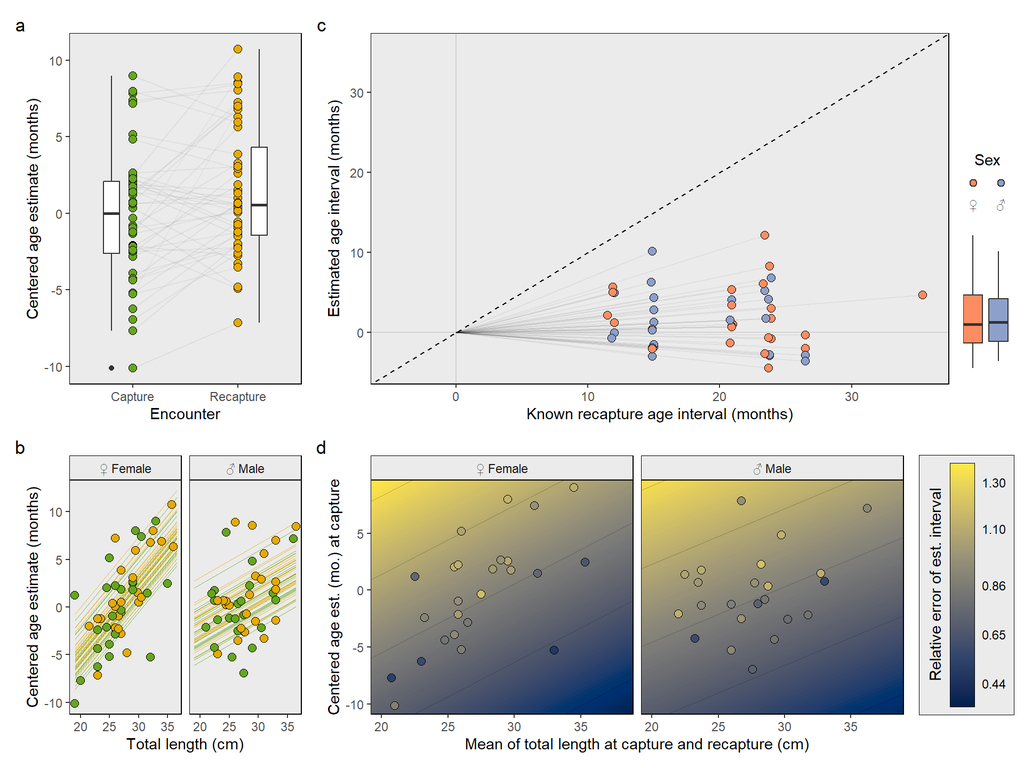

```r
# Figure-specific plotting definitions
POINT_SIZE <- 2.5
LINE_COLOUR <- "black"
LINE_ALPHA <- 0.05

# Top left
plot_capture_recapture_ages <- ageing_sample_estimates %>%
  dplyr::left_join(lobster_samples) %>%
  ggplot2::ggplot(
    ggplot2::aes(
      y = FairfieldAgeMonths,
      x = Encounter,
      fill = Encounter
    )
  ) +
  # Captioning
  ggplot2::ylab("Centered age estimate (months)") +
  # Connected points
  ggplot2::geom_line(
    mapping = ggplot2::aes(group = LobsterID),
    col = LINE_COLOUR,
    alpha = LINE_ALPHA
  ) +
  ggplot2::geom_point(
    pch = 21,
    size = POINT_SIZE,
    show.legend = FALSE
  ) +
  ggplot2::scale_fill_manual(values = c(CAP_COLOUR, RECAP_COLOUR)) +
  # Boxplots
  ggplot2::geom_boxplot(
    width = 0.15,
    fill = "white",
    position = ggplot2::position_nudge(x = c(-0.2, 0.2)),
    show.legend = FALSE
  ) +
  ggtheme_scatter

# Bottom left
plot_age_vs_size <- ageing_sample_estimates %>%
  dplyr::left_join(lobster_samples) %>%
  ggplot2::ggplot(
    ggplot2::aes(y = FairfieldAgeMonths,
        x = LengthCM,
        fill = Encounter,
        colour = Encounter)
  ) +
  ggplot2::xlab("Total length (cm)") +
  ggplot2::ylab("Centered age estimate (months)") +
  ggplot2::geom_line(
    mapping = ggplot2::aes(group = interaction(LobsterID, Encounter)),
    data = fairfield_plot_b_lme_predictions,
    alpha = 0.75,
    lwd = 0.25,
    show.legend = FALSE
  ) +
  ggplot2::geom_point(
    size = POINT_SIZE,
    pch = 21,
    colour = "black",
    show.legend = FALSE
  ) +
  ggplot2::facet_grid(
    cols = vars(Sex),
    labeller = labeller(
      Sex = c(
        `F` = "\u2640 Female",
        `M` = "\u2642 Male"
      )
    )
  ) +
  ggplot2::scale_colour_manual(values = c(CAP_COLOUR, RECAP_COLOUR)) +
  ggplot2::scale_fill_manual(values = c(CAP_COLOUR, RECAP_COLOUR)) +
  ggplot2::theme(
    strip.background = ggplot2::element_rect(
      fill = "#ebebeb",
      colour = "black"
    )
  ) +
  ggtheme_scatter

# Top right (main)
plot_predicted_vs_known_interval <- ageing_lobster_metrics %>%
  dplyr::left_join(lobsters) %>%
  ggplot2::ggplot(
    ggplot2::aes(
      x = KnownIntervalMonths,
      y = FairfieldIntervalMonths,
      fill = Sex
    )
  ) +
  # Coordinate system
  ggplot2::geom_abline(slope = 1, intercept = 0, lty = 2, lwd = 0.5) +
  ggplot2::geom_vline(xintercept = 0, lty = 1, lwd = 0.5, alpha = 0.1) +
  ggplot2::geom_hline(yintercept = 0, lty = 1, lwd = 0.5, alpha = 0.1) +
  ggplot2::xlab("Known recapture age interval (months)") +
  ggplot2::ylab("Estimated age interval (months)") +
  ggplot2::ylim(
    min(ageing_lobster_metrics$FairfieldIntervalMonths),
    max(ageing_lobster_metrics$KnownIntervalMonths)
  ) +
  ggplot2::xlim(
    min(ageing_lobster_metrics$FairfieldIntervalMonths),
    max(ageing_lobster_metrics$KnownIntervalMonths)
  ) +
  # Segments to points
  ggplot2::geom_segment(
    ggplot2::aes(
      x = 0,
      y = 0,
      xend = KnownIntervalMonths,
      yend = FairfieldIntervalMonths
    ),
    col = LINE_COLOUR,
    alpha = LINE_ALPHA
  ) +
  # Points on top
  ggplot2::geom_point(pch = 21, size = POINT_SIZE, show.legend = FALSE) +
  ggplot2::scale_fill_manual(values = c(FEMALE_COLOUR, MALE_COLOUR)) +
  ggtheme_scatter

# Top right (accessory)
plot_boxplot_of_predicted_intervals <- ageing_lobster_metrics %>%
  dplyr::left_join(lobsters) %>%
  ggplot2::ggplot(
    ggplot2::aes(
      y = FairfieldIntervalMonths,
      fill = Sex,
      x = ""
    )
  ) +
  ggplot2::ylim(
    min(ageing_lobster_metrics$FairfieldIntervalMonths),
    max(ageing_lobster_metrics$KnownIntervalMonths)
  ) +
  ggplot2::scale_x_discrete(expand = c(0, 0)) +
  ggplot2::scale_fill_manual(
    values = c(FEMALE_COLOUR, MALE_COLOUR),
    labels = c("\u2640", "\u2642")
  ) +
  ggplot2::geom_boxplot(
    width = 0.15,
    position = ggplot2::position_nudge(x = c(-0.1, 0.1)),
    key_glyph = draw_key_dotplot
  ) +
  ggplot2::theme(
    axis.ticks = ggplot2::element_blank(),
    axis.text = ggplot2::element_blank(),
    axis.title = ggplot2::element_blank(),
    panel.grid.major.x = ggplot2::element_blank(),
    panel.grid = ggplot2::element_blank(),
    panel.background = ggplot2::element_blank(),
    legend.position = "inside",
    legend.direction = "horizontal",
    legend.text.position = "bottom",
    legend.title.position = "top",
    legend.key.spacing = ggplot2::unit(0.35, "lines"),
    legend.title = ggplot2::element_text(hjust = 0.5, vjust = 0.15),
    legend.justification.inside = c(
      0.4, # x
      0.6 # y
    ),
    legend.key.width = ggplot2::unit(1, "lines")
  )

plot_interval_error_contour <- ageing_lobster_metrics %>%
  dplyr::left_join(lobsters) %>%
  ggplot2::ggplot(
    aes(
      x = MeanLengthCM,
      y = FairfieldCaptureAgeMonths,
    )
  ) +
  ggplot2::xlab("Mean of total length at capture and recapture (cm)") +
  ggplot2::ylab("Centered age est. (mo.) at capture") +
  geom_contour_filled(
    data = fairfield_plot_de_lm_predictions,
    bins = 100,
    mapping = aes(
      x = MeanLengthCM,
      y = FairfieldCaptureAgeMonths,
      z = FairfieldIntervalRelativeError
    ),
    show.legend = FALSE
  ) +
  geom_contour(
    data = fairfield_plot_de_lm_predictions,
    bins = 6,
    mapping = aes(
      x = MeanLengthCM,
      y = FairfieldCaptureAgeMonths,
      z = FairfieldIntervalRelativeError
    ),
    colour = "black",
    alpha = 0.25,
    linewidth = 0.25
  ) +
  ggplot2::scale_fill_viridis_d(option = "E") +
  ggnewscale::new_scale_fill() +
  ggplot2::scale_fill_viridis_c(
    option = "E",
    limits = c(
      min(fairfield_plot_de_lm_predictions$FairfieldIntervalRelativeError),
      max(fairfield_plot_de_lm_predictions$FairfieldIntervalRelativeError)
    ),
    breaks = signif(
      seq(
        min(fairfield_plot_de_lm_predictions$FairfieldIntervalRelativeError) + 0.1,
        max(fairfield_plot_de_lm_predictions$FairfieldIntervalRelativeError) - 0.1,
        length.out = 5
      ),
      digits = 2
    ),
    guide = ggplot2::guide_colorbar(
      title = "Relative error of est. interval",
      display = "raster",
      ticks.colour = NA,
      frame.colour = "black",
      frame.linewidth = 0.25,
      barheight = 11.9,
      title.position = "left",
      title.theme = ggplot2::element_text(angle = 90, hjust = 0.5)
    )
  ) +
  geom_point(
    aes(fill = FairfieldIntervalRelativeError),
    pch = 21,
    colour = "black",
    size = POINT_SIZE
  ) +
  scale_x_continuous(expand = c(0, 0)) +
  scale_y_continuous(expand = c(0, 0)) +
  facet_grid(
    cols = vars(Sex),
    labeller = labeller(
      Sex = c(
        `F` = "\u2640 Female",
        `M` = "\u2642 Male"
      )
    )
  ) +
  ggplot2::theme(
    strip.background = ggplot2::element_rect(
      fill = "#ebebeb",
      colour = "black"
    ),
    legend.background = element_rect(
      fill = "#ebebeb",
      colour = "black",
      linewidth = 0.25
    ),
    legend.box.margin = margin(-17.25,-15,0,0)
  ) +
  ggtheme_scatter

# Patchwork together
plot_fairfield_ageing_accuracy <- (
  (
    plot_capture_recapture_ages /
      plot_age_vs_size +
      patchwork::plot_layout(nrow = 2, heights = c(4.5, 3))
  ) | (
    (
      (
        plot_predicted_vs_known_interval |
          patchwork::plot_spacer() |
          (
            # Stripped boxplot has no panel label
            plot_boxplot_of_predicted_intervals +
              patchwork::plot_layout(tag_level = "new")
          )
      ) + patchwork::plot_layout(ncol = 3, widths = c(0.96, -0.035, 0.075))
    ) / (
      plot_interval_error_contour + guide_area() + plot_layout(widths = c(10,0))
    )
  ) + patchwork::plot_layout(heights = c(4.5,3))
) +
  patchwork::plot_layout(widths = c(2, 5.5)) +
  patchwork::plot_annotation(tag_levels = "a")
```

## Step 4: Filter loci with EWAS

### rDNA EWAS

I run an “EWAS” (Epigenome-Wide Association Scan) on the rDNA region. This is first and foremost to filter loci for effect size before re-training. First, define the significance level and type of p-value adjustment:

```r
EWAS_SIGNIFICANCE_LEVEL <- 0.05
EWAS_SIGNIFICANCE_ADJUSTMENT <- "fdr"
```

Then run the EWAS regressions themselves and find adjusted p-values. The EWAS regresses months passed at the different loci with lobster ID as a random factor (i.e. one intercept per lobster) using the M values.

```r
number_of_loci <- length(loci_in_order)

ewas_lmer_regressions <- vector(mode = "list", length = number_of_loci)
ewas_lmer_p_values <- vector(mode = "numeric", length = number_of_loci)
ewas_lmer_effect_sizes <- vector(mode = "numeric", length = number_of_loci)
ewas_lmer_r2_marginals <- vector(mode = "numeric", length = number_of_loci)
names(ewas_lmer_regressions) <- loci_in_order
names(ewas_lmer_p_values) <- loci_in_order
names(ewas_lmer_effect_sizes) <- loci_in_order
names(ewas_lmer_r2_marginals) <- loci_in_order

for (locus in loci_in_order)
{
  ewas_locus_lmer <- lobster_samples %>%
    dplyr::left_join(sample_methylation_mvalues) %>%
    lmerTest::lmer(
      data = .,
      formula = .[[locus]] ~ MonthsPassed + LengthCM * Sex +
        (1 | LobsterID) + (1 | Year/Month) # Year/Month is mostly singular ...
    )
  ewas_lmer_regressions[[locus]] <- ewas_locus_lmer

  ewas_locus_p_value <- summary(ewas_locus_lmer)$coefficients[2, 5]
  ewas_locus_effect_size <- summary(ewas_locus_lmer)$coefficients[2, 1]
  ewas_locus_r2_marginal <- MuMIn::r.squaredGLMM(ewas_locus_lmer)[1]
  ewas_lmer_p_values[[locus]] <- ewas_locus_p_value
  ewas_lmer_effect_sizes[[locus]] <- ewas_locus_effect_size
  ewas_lmer_r2_marginals[[locus]] <- ewas_locus_r2_marginal
}

ewas_lmer_p_values_adjusted <- ewas_lmer_p_values %>%
  stats::p.adjust(method = EWAS_SIGNIFICANCE_ADJUSTMENT)

ewas_results <- data.frame(
  `Locus` = factor(loci_in_order, levels = loci_in_order),
  `EffectSize` = ewas_lmer_effect_sizes,
  `MarginalR2` = ewas_lmer_r2_marginals,
  `UnadjustedPValues` = ewas_lmer_p_values,
  `AdjustedPValues` = ewas_lmer_p_values_adjusted
)

ewas_significant_loci <- ewas_results$AdjustedPValues %>%
  magrittr::is_less_than(EWAS_SIGNIFICANCE_LEVEL) %>%
  which() %>%
  ewas_results$Locus[.]
```

### Manhattan plot

The EWAS loci can be plotted in a typical Manhattan plot to show which are significant. This will be part of a multipanel figure later.

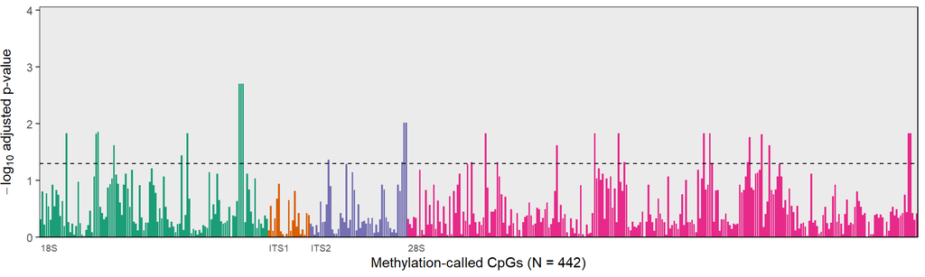

```r
# This is unnecessarily complicated ...
rdna_region_colours <- PLOT_LOCUS_LABELS %>%
  # Vector of region start indices:
  { which(. != "") } %>%
  # Vector of region start and end indices:
  append(length(PLOT_LOCUS_LABELS) + 1) %>%
  {
    number_of_regions <- length(.) - 1
    region_colours <- RColorBrewer::brewer.pal(number_of_regions, "Dark2")
    point_colour_sequence <- c()

    for (region_number in seq_len(number_of_regions))
    {
      points_in_region <- .[region_number + 1] - .[region_number]
      colour_reps <- rep(region_colours[region_number], points_in_region)
      point_colour_sequence %<>% append(colour_reps)
    }
    point_colour_sequence # Final colours!
  }

names(rdna_region_colours) <- loci_in_order

plot_ewas_manhattan <- ewas_results %>%
  ggplot2::ggplot(
    data = .,
    mapping = ggplot2::aes(
      y = -log10(AdjustedPValues),
      x = Locus
    )
  ) +
  ggplot2::xlab("Methylation-called CpGs (N = 442)") +
  ggplot2::ylab(expression(-log["10"]*" adjusted p-value")) +
  ggplot2::geom_col(fill = rdna_region_colours) +
  ggplot2::scale_y_continuous(expand = expansion(mult = c(0, 0.5))) +
  ggplot2::scale_x_discrete(labels = PLOT_LOCUS_LABELS) +
  ggplot2::geom_hline(yintercept = -log10(EWAS_SIGNIFICANCE_LEVEL), lty = 2) +
  ggplot2::theme(
    panel.grid = ggplot2::element_blank(),
    panel.border = ggplot2::element_rect(fill = NA, colour = "black"),
    axis.title.y = ggplot2::element_text(vjust = 3.5),
    axis.text.x = ggplot2::element_text(hjust = 0, size = 7),
    axis.ticks.x = ggplot2::element_blank()
  )
```

### Effect size plot

Next to the Manhattan plot, it makes sense to show the effect sizes of the significant loci in context. To do this, I make a reasonably simple plot. It will also be part of the multipanel figure, but here it is:

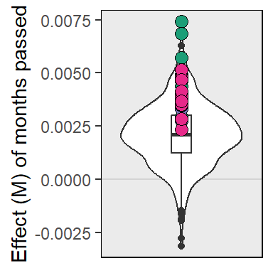

```r
plot_ewas_effect_sizes
```

### PCA over significant loci

Lars (Grønvold) suggested that I could run a PCA of methylation at the significant loci from the EWAS. To do that, I wrangle the data so I retain only those loci, then run a PCA and collect the necessary stats from the pca object. I also format the PC1 and PC2 values in both long and wide format for plotting:

```r
ewas_pca_lobster_samples <- lobster_samples %>%
  left_join(sample_methylation_mvalues) %>%
  dplyr::select(
    LobsterID,
    Encounter,
    tidyr::all_of(ewas_significant_loci)
  )

ewas_pca <- ewas_pca_lobster_samples %>%
  dplyr::select(tidyr::all_of(ewas_significant_loci)) %>%
  stats::prcomp()

ewas_pca_importances <- ewas_pca %>%
  summary() %>%
  magrittr::use_series("importance") %>%
  { .["Proportion of Variance", ] } %>%
  magrittr::multiply_by(100) %>%
  round(digits = 1)

ewas_pca_data_longer <- ewas_pca %>%
  magrittr::use_series("x") %>% # Principal components
  as.data.frame() %>%
  dplyr::select("PC1", "PC2") %>%
  cbind(ewas_pca_lobster_samples, .) %>%
  dplyr::select(LobsterID, Encounter, PC1, PC2)

ewas_pca_data_wider <- ewas_pca_data_longer %>%
  tidyr::pivot_wider(
    values_from = c("PC1", "PC2"),
    names_from = c("Encounter")
  )
```

### Combined EWAS plot

Then I make a plot of the PCA where arrows combine capture and recapture, so I can see the directionality of lobsters on PC1 and PC2 between capture and recapture. I also add box plots to show the distribution of capture and recapture samples on the principal components. Combining everything gives the final plot from the EWAS:

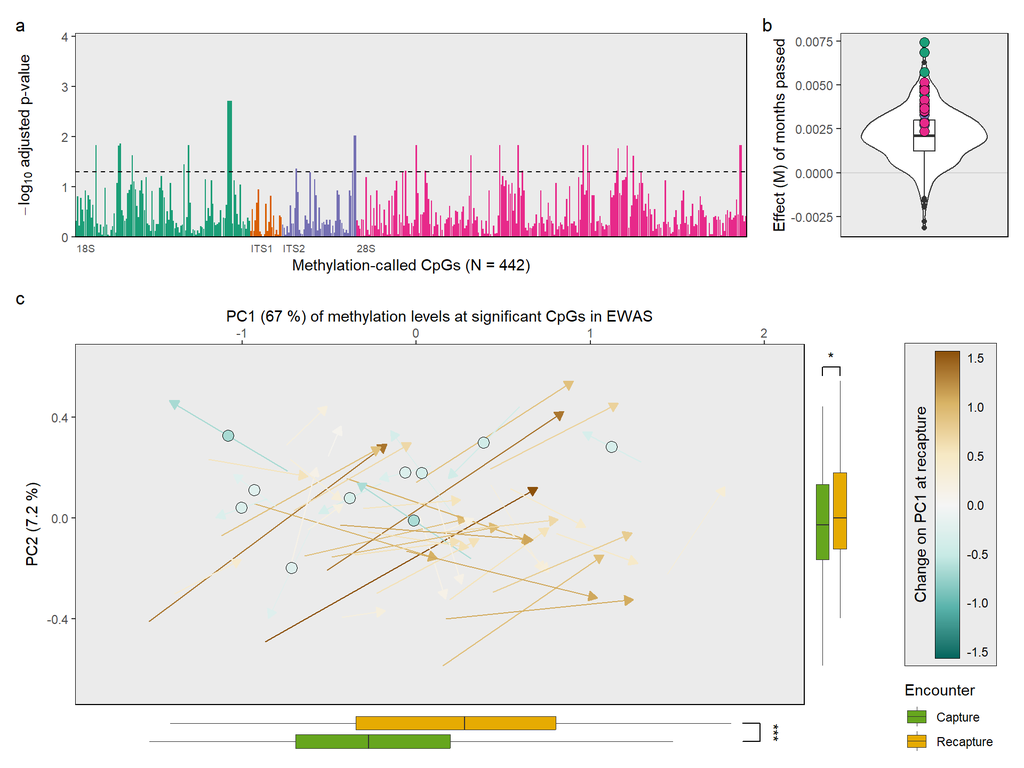

```r
EWAS_PCA_XYLIMS_AESTHETIC_SCALEFACTOR <- 1.15

ewas_pca_xlims <- c(
  min(ewas_pca_data_longer$PC1) * EWAS_PCA_XYLIMS_AESTHETIC_SCALEFACTOR,
  max(ewas_pca_data_longer$PC1) * EWAS_PCA_XYLIMS_AESTHETIC_SCALEFACTOR
)

ewas_pca_ylims <- c(
  min(ewas_pca_data_longer$PC2) * EWAS_PCA_XYLIMS_AESTHETIC_SCALEFACTOR,
  max(ewas_pca_data_longer$PC2) * EWAS_PCA_XYLIMS_AESTHETIC_SCALEFACTOR
)

plot_ewas_pca <- ewas_pca_data_wider %>%
  ggplot2::ggplot() +
  ggplot2::geom_segment(
    ggplot2::aes(
      x = PC1_Capture,
      xend = PC1_Recapture,
      y = PC2_Capture,
      yend = PC2_Recapture,
      colour = PC1_Recapture - PC1_Capture
    ),
    arrow = grid::arrow(
      length = ggplot2::unit(0.5, "lines"),
      type = "closed"
    )
  ) +
  ggplot2::geom_point(
    aes(
      x = (PC1_Recapture + PC1_Capture) / 2,
      y = (PC2_Recapture + PC2_Capture) / 2,
      fill = PC1_Recapture - PC1_Capture,
      alpha = ifelse(PC1_Recapture < PC1_Capture, FALSE, TRUE)
    ),
    pch = 21,
    size = 3.5,
    show.legend = FALSE
  ) +
  ggplot2::xlab(
    paste0(
      "PC1 (",
      ewas_pca_importances["PC1"],
      " %) of methylation levels at significant CpGs in EWAS"
    )
    ) +
  ggplot2::ylab(paste0("PC2 (", ewas_pca_importances["PC2"], " %)")) +
  ggplot2::scale_x_continuous(position = "top", limits = ewas_pca_xlims) +
  ggplot2::scale_y_continuous(limits = ewas_pca_ylims) +
  ggplot2::scale_alpha_manual(values = c(1, 0)) +
  ggplot2::scale_colour_distiller(
      aesthetics = c("fill", "colour"),
      guide = ggplot2::guide_colorbar(
        title = "Change on PC1 at recapture",
        display = "raster",
        ticks.colour = NA,
        frame.colour = "black",
        frame.linewidth = 0.25,
        title.position = "left",
        title.theme = ggplot2::element_text(angle = 90, hjust = 0.5),
        barheight = 15
      ),
      limits = ggh4x::center_limits(),
      palette = "BrBG",
      type = "div"
  ) +
  ggplot2::theme(
    panel.grid = ggplot2::element_blank(),
    panel.border = ggplot2::element_rect(fill = NA, colour = "black"),
    legend.background = ggplot2::element_rect(
      colour = "black",
      fill = "#ebebeb",
      linewidth = 0.25
    )
  )

plot_ewas_pca_pc1_densities <- ewas_pca_data_longer %>%
  ggplot2::ggplot(
    ggplot2::aes(
      x = PC1,
      y = Encounter,
      fill = Encounter
    )
  ) +
  ggplot2::scale_fill_manual(values = c(CAP_COLOUR, RECAP_COLOUR)) +
  ggplot2::scale_x_continuous(limits = ewas_pca_xlims) +
  ggplot2::geom_boxplot(show.legend = FALSE, lwd = 0.25) +
  ggsignif::geom_signif(
    test = "t.test",
    test.args = list("paired" = TRUE),
    map_signif_level = TRUE,
    comparisons = list(c("Capture", "Recapture"))
  ) +
  ggplot2::theme_void()

plot_ewas_pca_pc2_densities <- ewas_pca_data_longer %>%
  ggplot2::ggplot(
    ggplot2::aes(
      y = PC2,
      x = Encounter,
      fill = Encounter
    )
  ) +
  ggplot2::scale_fill_manual(values = c(CAP_COLOUR, RECAP_COLOUR)) +
  ggplot2::scale_y_continuous(limits = ewas_pca_ylims) +
  ggplot2::geom_boxplot(lwd = 0.25) +
  ggsignif::geom_signif(
    test = "t.test",
    test.args = list("paired" = TRUE),
    map_signif_level = TRUE,
    comparisons = list(c("Capture", "Recapture"))
  ) +
  ggplot2::theme_void()

plot_ewas_combined <- (
  # Top row of plots
  ( plot_ewas_manhattan | plot_ewas_effect_sizes ) +
    # Layout for top row
    patchwork::plot_layout(widths = c(8, 2))) /
  # Bottom row of plots
  (
    # Collects bottom row and guide area
    (
      # "Top row" of bottom row, i.e. PC1 density plot
      (
        ( plot_ewas_pca |
            (
              plot_ewas_pca_pc2_densities +
                patchwork::plot_layout(tag_level = "new")
            )
        ) + patchwork::plot_layout(widths = c(9.5, 0.5, 0.5)) # Top row layout
      ) /
        # Bottom row of bottom row
        (
          (
            plot_ewas_pca_pc1_densities
          ) + patchwork::plot_layout(widths = c(9.5, 1.0), tag_level = "new")
        ) +
        # Layout of bottom row
        patchwork::plot_layout(heights = c(9, 1), guides = "collect") |
        # Add guide area on side (|)
        patchwork::guide_area()
    ) + patchwork::plot_layout(widths = c(200, 1)) # Layout of row | guide_area
  ) +
  # Plot-wide (top / bottom layout and plot annotation)
  patchwork::plot_layout(heights = c(2.5, 5)) +
  patchwork::plot_annotation(tag_levels = "a")
```

Paired t-test results for the box plots:

```r
# Implemented as linear mixed effect models for simplicity of data wrangling
ewas_pca_data_longer %>%
  lmerTest::lmer( # For PC1
    PC1 ~ Encounter + (1 | LobsterID),
    data = .
  ) %>% summary()
```

```
## Linear mixed model fit by REML. t-tests use Satterthwaite's method [
## lmerModLmerTest]
## Formula: PC1 ~ Encounter + (1 | LobsterID)
##    Data: .
##
## REML criterion at convergence: 176.1
##
## Scaled residuals:
##      Min       1Q   Median       3Q      Max
## -1.93926 -0.54424  0.05252  0.54811  1.52681
##
## Random effects:
##  Groups    Name        Variance Std.Dev.
##  LobsterID (Intercept) 0.3242   0.5694
##  Residual              0.1536   0.3919
## Number of obs: 96, groups:  LobsterID, 48
##
## Fixed effects:
##                    Estimate Std. Error       df t value Pr(>|t|)
## (Intercept)        -0.21429    0.09977 64.36722  -2.148   0.0355 *
## EncounterRecapture  0.42857    0.08000 47.00000   5.357 2.49e-06 ***
## ---
## Signif. codes:  0 '***' 0.001 '**' 0.01 '*' 0.05 '.' 0.1 ' ' 1
##
## Correlation of Fixed Effects:
##             (Intr)
## EncntrRcptr -0.401
```

```r
ewas_pca_data_longer %>%
  lmerTest::lmer( # For PC2
    PC2 ~ Encounter + (1 | LobsterID),
    data = .
  ) %>% summary()
```

```
## Linear mixed model fit by REML. t-tests use Satterthwaite's method [
## lmerModLmerTest]
## Formula: PC2 ~ Encounter + (1 | LobsterID)
##    Data: .
##
## REML criterion at convergence: -5.5
##
## Scaled residuals:
##      Min       1Q   Median       3Q      Max
## -1.88853 -0.60388  0.00691  0.70298  1.74261
##
## Random effects:
##  Groups    Name        Variance Std.Dev.
##  LobsterID (Intercept) 0.01940  0.1393
##  Residual              0.03501  0.1871
## Number of obs: 96, groups:  LobsterID, 48
##
## Fixed effects:
##                    Estimate Std. Error       df t value Pr(>|t|)
## (Intercept)        -0.04144    0.03367 83.39675  -1.231   0.2218
## EncounterRecapture  0.08289    0.03819 47.00000   2.170   0.0351 *
## ---
## Signif. codes:  0 '***' 0.001 '**' 0.01 '*' 0.05 '.' 0.1 ' ' 1
##
## Correlation of Fixed Effects:
##             (Intr)
## EncntrRcptr -0.567
```

The labelled lobsters in the PCA Plot are seemingly heterogeneous…

```r
labelled_lobster_ids <- ewas_pca_data_wider %>%
  dplyr::filter(PC1_Recapture < PC1_Capture) %>%
  dplyr::select(LobsterID) %>%
  unlist()

labelled_lobsters_data <- lobsters %>%
  dplyr::filter(LobsterID %in% labelled_lobster_ids)

labelled_lobsters_data %>%
  kableExtra::kbl() %>%
  kableExtra::kable_paper() %>%
  kableExtra::scroll_box(width = "100%")
```

| LobsterID | ZoneID | Sex | CaptureDate | RecaptureDate | Seasonality | CaptureIntervalDays | CaptureIntervalBins | CaptureIntervalMonths | CaptureEggs | RecaptureEggs | EggsClass | CaptureLengthCM | RecaptureLengthCM | MeanLengthCM | GrowthCM | CaptureSampleNumber | RecaptureSampleNumber |
| --- | --- | --- | --- | --- | --- | --- | --- | --- | --- | --- | --- | --- | --- | --- | --- | --- | --- |
| 00834 | M | M | 2021-09-16 | 2023-12-02 | 912 | 807 | 27 mo. | 26.5 | NA | NA | NA | 32.5 | 33.0 | 32.75 | 0.5 | 13 | 51 |
| C0621 | M | F | 2021-12-05 | 2023-12-02 | 1212 | 727 | 24 mo. | 23.8 | FALSE | FALSE | – | 24.5 | 26.5 | 25.50 | 2.0 | 18 | 66 |
| 00737 | M | M | 2021-12-08 | 2023-12-02 | 1212 | 724 | 24 mo. | 23.7 | NA | NA | NA | 27.5 | 29.5 | 28.50 | 2.0 | 20 | 68 |
| C0126 | S | F | 2020-09-18 | 2022-09-02 | 99 | 714 | 24 mo. | 23.4 | TRUE | FALSE | +- | 33.0 | 36.0 | 34.50 | 3.0 | 24 | 94 |
| C0385 | M | M | 2021-12-06 | 2023-09-05 | 129 | 638 | 21 mo. | 20.9 | NA | NA | NA | 27.0 | 28.5 | 27.75 | 1.5 | 27 | 74 |
| 00661 | S | F | 2021-12-08 | 2023-09-06 | 129 | 637 | 21 mo. | 20.9 | FALSE | FALSE | – | 30.5 | 32.5 | 31.50 | 2.0 | 6 | 75 |
| T0572 | M | M | 2022-09-04 | 2023-12-02 | 912 | 454 | 15 mo. | 14.9 | NA | NA | NA | 29.0 | 30.5 | 29.75 | 1.5 | 34 | 81 |
| T0553 | M | F | 2022-09-04 | 2023-12-02 | 912 | 454 | 15 mo. | 14.9 | FALSE | FALSE | – | 29.0 | 29.0 | 29.00 | 0.0 | 36 | 83 |
| T0027 | M | F | 2022-09-06 | 2023-12-03 | 912 | 453 | 15 mo. | 14.9 | TRUE | FALSE | +- | 29.5 | 29.5 | 29.50 | 0.0 | 39 | 86 |
| T0043 | M | M | 2022-09-06 | 2023-12-02 | 912 | 452 | 15 mo. | 14.8 | NA | NA | NA | 33.0 | 33.0 | 33.00 | 0.0 | 40 | 87 |

```r
# Mean length stats
labelled_lobsters_data %>%
  magrittr::use_series(MeanLengthCM) %>%
  {
    range(.) %>% print()
    mean(.) %>% print()
    sd(.) %>% print()
  }
```

```
## [1] 25.5 34.5
## [1] 30.175
## [1] 2.741274
```

```r
# Mean growth stats
labelled_lobsters_data %>%
  magrittr::use_series(GrowthCM) %>%
  {
    range(.) %>% print()
    mean(.) %>% print()
    sd(.) %>% print()
  }
```

```
## [1] 0 3
## [1] 1.25
## [1] 1.06066
```

With EWAS-significant loci, I can now train new models.

## Step 5: Training a new model

I train two new models to see if I can describe the age intervals with linear combinations of CpG methylation changes. First across all loci, then across the EWAS loci across all loci. I use `MonthsPassed` per sample as a response, and M values as predictors.

### Capture-recapture methylation models

#### Functionalise model training

For simplicity, I quickly functionalise model training here …

```r
train_penalised_regression_from_dataset <- function(
    ids_and_responses = lobster_samples %>%
      dplyr::select(
        SampleNumber,
        MonthsPassed
      ),
    ids_and_predictors = sample_methylation_mvalues,
    alphas = seq(from = 0.5, to = 1.0, by = 0.5),
    lambdas = 10 ^ seq(from = log10(1e-3), to = log10(1e3), length.out = 100),
    cross_validation_settings = caret::trainControl(
      "repeatedcv", number = 10, repeats = 10
    ),
    method = "glmnet",
    family = "gaussian"
)
{
  ids_responses_and_predictors_combined <- ids_and_responses %>%
    dplyr::left_join(ids_and_predictors)

  train_versus_test_split <- ids_responses_and_predictors_combined %>%
    rsample::initial_split(strata = MonthsPassed)

  ids_responses_and_predictors_train <- rsample::training(train_versus_test_split)
  ids_responses_and_predictors_test <- rsample::testing(train_versus_test_split)

  responses_train <- ids_responses_and_predictors_train %>%
    dplyr::select(MonthsPassed)
  predictors_train <- ids_responses_and_predictors_train %>%
    dplyr::select(dplyr::contains("CpG"))
  responses_test <- ids_responses_and_predictors_test %>%
    dplyr::select(MonthsPassed)
  predictors_test <- ids_responses_and_predictors_test %>%
    dplyr::select(dplyr::contains("CpG"))

  total_available_predictors <- ncol(predictors_train)

  near_zero_variance_cpgs <- predictors_train %>%
    caret::nearZeroVar(names = TRUE)

  predictors_train %<>% dplyr::select(-near_zero_variance_cpgs)
  predictors_test %<>% dplyr::select(-near_zero_variance_cpgs)

  highly_correlated_cpgs <- predictors_train %>%
    stats::cor() %>%
    caret::findCorrelation(names = TRUE, exact = TRUE)

  predictors_train %<>% dplyr::select(-highly_correlated_cpgs)
  predictors_test %<>% dplyr::select(-highly_correlated_cpgs)

  # Make transformer for scaling/centering based on TRAINING DATA ONLY
  transformer_predictors_train <- caret::preProcess(predictors_train)

  # Scale and centre training and testing sets
  predictors_train %<>% stats::predict(object = transformer_predictors_train)
  predictors_test %<>% stats::predict(object = transformer_predictors_train)

  # Train model
  penalised_regression <- caret::train(
    x = as.matrix(predictors_train),
    y = unlist(responses_train),
    method = method,
    family = family,
    trControl = cross_validation_settings,
    tuneGrid = expand.grid(
      alpha = alphas,
      lambda = lambdas
    )
  )

  return(
    list(
      `Penalised Regression` = penalised_regression,
      `Test IDs` = ids_responses_and_predictors_test$SampleNumber,
      `Train IDs` = ids_responses_and_predictors_train$SampleNumber,
      `Test responses` = responses_test,
      `Train responses` = responses_train,
      `Train predictors` = predictors_train,
      `Test predictors` = predictors_test,
      `Total available CpGs` = total_available_predictors,
      `Total available post-filtering CpGs` = total_available_predictors %>%
        subtract(length(near_zero_variance_cpgs)) %>%
        subtract(length(highly_correlated_cpgs)),
      `Non-zero coefficients` = penalised_regression %>%
        { coef(.$finalModel, s = .$bestTune[["lambda"]]) } %>%
        as.matrix() %>%
        as.data.frame() %>%
        dplyr::filter(s1 != 0) %>%
        slice(-1),
      `Intercept` = penalised_regression %>%
        { coef(.$finalModel, s = .$bestTune[["lambda"]]) } %>%
        as.matrix() %>%
        as.data.frame() %>%
        dplyr::filter(s1 != 0) %>%
        slice(1),
      `Metrics` = as.data.frame(penalised_regression$bestTune) %>%
        dplyr::left_join(
          as.data.frame(penalised_regression$results),
          by = c("alpha", "lambda")
        )
    )
  )
}
```

### Run model training

```r
all_loci_regression <- train_penalised_regression_from_dataset(alphas = 0.5)
ewas_loci_regression <- train_penalised_regression_from_dataset(
  alphas = 0.5,
  ids_and_predictors = dplyr::select(
    sample_methylation_mvalues,
    SampleNumber,
    tidyr::all_of(ewas_significant_loci)
  )
)
```

Here are the non-zero coefficients and accuracy metrics from each regression:

```r
all_loci_regression$`Non-zero coefficients`
```

```
##                              s1
## CpG_18S_ITS1_501   0.0208216519
## CpG_18S_ITS1_579   0.2210118296
## CpG_18S_ITS1_952   0.4716859266
## CpG_18S_ITS1_1059 -0.0003564268
## CpG_18S_ITS1_1200  0.6765301831
## CpG_18S_ITS1_1383 -0.4527882281
## CpG_18S_ITS1_1595  0.7793071971
## CpG_18S_ITS1_1604  0.5599072247
## CpG_18S_ITS1_1626  1.5178997613
## CpG_18S_ITS1_1630  0.6994618308
## CpG_18S_ITS1_1931 -1.0911723763
## CpG_18S_ITS1_1980 -0.0656612873
## CpG_18S_ITS1_2005 -0.8500989745
## CpG_18S_ITS1_2009 -0.0136380417
## CpG_ITS2_28S_553   1.3761410570
## CpG_ITS2_28S_1332  1.4079946259
## CpG_ITS2_28S_1513 -1.8738752004
## CpG_ITS2_28S_1518 -0.5144583809
## CpG_ITS2_28S_1685 -0.0507266985
## CpG_ITS2_28S_2033 -0.4605795705
## CpG_ITS2_28S_2313 -0.7790224937
## CpG_ITS2_28S_2656  0.4766898536
## CpG_ITS2_28S_2851  0.5939085451
## CpG_ITS2_28S_3177  0.1252046444
## CpG_ITS2_28S_3363 -0.6636491356
## CpG_ITS2_28S_3540  0.0905081027
## CpG_ITS2_28S_3706  0.3447898731
## CpG_ITS2_28S_3944  1.6630047440
```

```r
all_loci_regression$`Metrics`
```

```
##   alpha   lambda     RMSE  Rsquared      MAE  RMSESD RsquaredSD    MAESD
## 1   0.5 1.873817 10.18525 0.2288881 8.918313 1.75244  0.2500932 1.515488
```

```r
ewas_loci_regression$`Non-zero coefficients`
```

```
##                          s1
## CpG_18S_ITS1_1626 2.4038079
## CpG_18S_ITS1_1630 0.2382801
## CpG_ITS2_28S_1332 0.5660222
```

```r
ewas_loci_regression$`Metrics`
```

```
##   alpha   lambda     RMSE  Rsquared      MAE   RMSESD RsquaredSD    MAESD
## 1   0.5 1.873817 9.803776 0.2099851 8.913268 1.357874  0.1900362 1.382624
```

### Collate predictions

I collate the predictions from each model and bind the training and test predictions to the appropriate rows in `ageing_sample_estimates` data for later:

```r
all_loci_predictions <- data.frame(
  SampleNumber = c(
    all_loci_regression$`Train IDs`,
    all_loci_regression$`Test IDs`
  ),
  TestTrain = c(
    rep("Train", length(all_loci_regression$`Train IDs`)),
    rep("Test", length(all_loci_regression$`Test IDs`))
  ),
  AllLociMonths = c(
    predict(all_loci_regression$`Penalised Regression`),
    predict(
      all_loci_regression$`Penalised Regression`,
      all_loci_regression$`Test predictors`
    )
  )
)

ewas_loci_predictions <- data.frame(
    SampleNumber = c(
    ewas_loci_regression$`Train IDs`,
    ewas_loci_regression$`Test IDs`
  ),
  TestTrain = c(
    rep("Train", length(ewas_loci_regression$`Train IDs`)),
    rep("Test", length(ewas_loci_regression$`Test IDs`))
  ),
  EWASLociMonths = c(
    predict(ewas_loci_regression$`Penalised Regression`),
    predict(
      ewas_loci_regression$`Penalised Regression`,
      ewas_loci_regression$`Test predictors`
    )
  )
)

penalised_regressions_predictions <- all_loci_predictions %>%
  full_join(ewas_loci_predictions)

# Join all data plus real months passed.
ageing_sample_estimates %<>%
  left_join(penalised_regressions_predictions) %>%
  left_join(lobster_samples %>% dplyr::select(SampleNumber, MonthsPassed))
```

## Step 6: Model comparison

### Venn diagram of different models

We can see which loci the models share with each other and with the original Fairfield paper model with a Venn diagram:

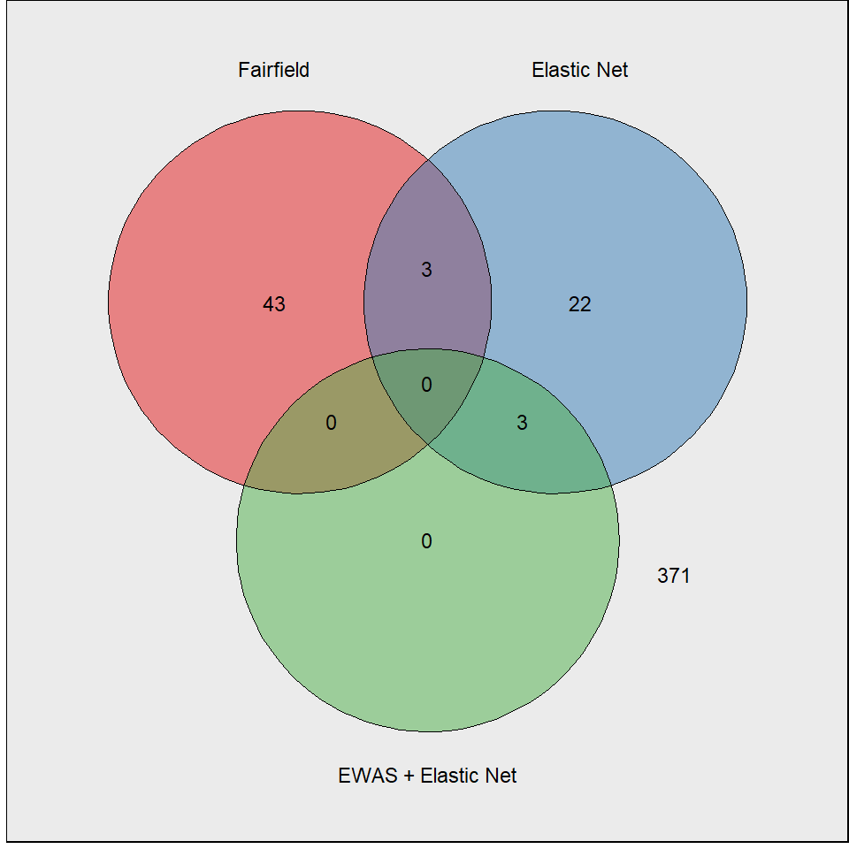

```r
venn_diagram_data <- tidyr::tibble(
  Value = loci_in_order,
  `Fairfield` = loci_in_order %in% names(FAIRFIELD_ELASTICNET_CpG),
  `Elastic Net` = loci_in_order %in% rownames(all_loci_regression$`Non-zero coefficients`),
  `EWAS + Elastic Net` = loci_in_order %in% rownames(ewas_loci_regression$`Non-zero coefficients`)
)

plot_venn_diagram <- venn_diagram_data %>%
  ggplot2::ggplot(
    ggplot2::aes(
      A = `Fairfield`,
      B = `Elastic Net`,
      C = `EWAS + Elastic Net`,
    )
  ) +
  ggvenn::geom_venn(
    show_percentage = FALSE,
    stroke_size = 0.25,
    text_size = 3,
    set_name_size = 3,
    fill_color = MODEL_COLOURS
  ) +
  ggplot2::coord_fixed() +
  ggplot2::theme(
    panel.grid = ggplot2::element_blank(),
    panel.border = ggplot2::element_rect(fill = NA, colour = "black"),
    axis.ticks = ggplot2::element_blank(),
    axis.text = ggplot2::element_blank(),
    plot.margin = ggplot2::unit(c(0,0,0,0), "lines")
  )
```

### Compare interval estimates

I compare the interval estimation performance of my two new models and the Fairfield model. As I did in Step 3, I have to calculate the intervals and related metrics:

```r
for (row in seq_len(nrow(ageing_lobster_metrics)))
{
  lobster_id <- ageing_lobster_metrics$LobsterID[row]
  lobster_known_interval <- ageing_lobster_metrics$KnownIntervalMonths[row]

  capture_sample <- ageing_lobster_metrics$CaptureSampleNumber[row]
  recapture_sample <- ageing_lobster_metrics$RecaptureSampleNumber[row]

  lobster_age_estimates <- ageing_sample_estimates %>%
    dplyr::filter(LobsterID == lobster_id)

  all_loci_age_estimates <- lobster_age_estimates %>%
    dplyr::select(SampleNumber, AllLociMonths) %>%
    tidyr::drop_na(AllLociMonths)

  all_loci_capture_estimate <- all_loci_age_estimates %>%
    dplyr::filter(SampleNumber == capture_sample) %>%
    magrittr::use_series(AllLociMonths)

  all_loci_recapture_estimate <- all_loci_age_estimates %>%
    dplyr::filter(SampleNumber == recapture_sample) %>%
    magrittr::use_series(AllLociMonths)

  ewas_loci_age_estimates <- lobster_age_estimates %>%
    dplyr::select(SampleNumber, EWASLociMonths) %>%
    tidyr::drop_na()

  ewas_loci_capture_estimate <- ewas_loci_age_estimates %>%
    dplyr::filter(SampleNumber == capture_sample) %>%
    magrittr::use_series(EWASLociMonths)

  ewas_loci_recapture_estimate <- ewas_loci_age_estimates %>%
    dplyr::filter(SampleNumber == recapture_sample) %>%
    magrittr::use_series(EWASLociMonths)

  all_loci_estimates <- c(all_loci_capture_estimate, all_loci_recapture_estimate)
  all_loci_interval_estimate <- all_loci_estimates[2] - all_loci_estimates[1]

  all_loci_interval_error <- lobster_known_interval - all_loci_interval_estimate
  all_loci_abs_error <- abs(all_loci_interval_error)
  all_loci_relative_error <- all_loci_abs_error / lobster_known_interval

  ewas_loci_estimates <- c(ewas_loci_capture_estimate, ewas_loci_recapture_estimate)
  ewas_loci_interval_estimate <- ewas_loci_estimates[2] - ewas_loci_estimates[1]

  ewas_loci_interval_error <- lobster_known_interval - ewas_loci_interval_estimate
  ewas_loci_abs_error <- abs(ewas_loci_interval_error)
  ewas_loci_relative_error <- ewas_loci_abs_error / lobster_known_interval

  ageing_lobster_metrics$AllLociCaptureMonths[row] <- all_loci_estimates[1]
  ageing_lobster_metrics$AllLociRecaptureMonths[row] <- all_loci_estimates[2]
  ageing_lobster_metrics$AllLociIntervalMonths[row] <- all_loci_interval_estimate
  ageing_lobster_metrics$AllLociIntervalError[row] <- all_loci_interval_error
  ageing_lobster_metrics$AllLociIntervalAbsError[row] <- all_loci_abs_error
  ageing_lobster_metrics$AllLociIntervalRelativeError[row] <- all_loci_relative_error

  ageing_lobster_metrics$EWASLociCaptureMonths[row] <- ewas_loci_estimates[1]
  ageing_lobster_metrics$EWASLociRecaptureMonths[row] <- ewas_loci_estimates[2]
  ageing_lobster_metrics$EWASLociIntervalMonths[row] <- ewas_loci_interval_estimate
  ageing_lobster_metrics$EWASLociIntervalError[row] <- ewas_loci_interval_error
  ageing_lobster_metrics$EWASLociIntervalAbsError[row] <- ewas_loci_abs_error
  ageing_lobster_metrics$EWASLociIntervalRelativeError[row] <- ewas_loci_relative_error
}
```

Then, reformat the dataset …

```r
ageing_lobster_metrics_long <- ageing_lobster_metrics %>%
  dplyr::select(LobsterID, contains("Interval")) %>%
  rename(RealMonths = KnownIntervalMonths) %>%
  tidyr::pivot_longer(
    cols = contains("Interval"),
    names_pattern = "(.*)Interval(.*)",
    names_to = c("Model", "Metric"),
    names_transform = as.factor
  ) %>%
  tidyr::pivot_wider(names_from = Metric) %>%
  dplyr::mutate(
    Model = factor(Model, levels = c("Fairfield", "AllLoci", "EWASLoci"))
  )
```

… make a comparison plot for later:

```r
plot_model_comparison <- ageing_lobster_metrics_long %>%
  ggplot2::ggplot(
    ggplot2::aes(
      x = Model,
      y = RelativeError,
      fill = Model
    )
  ) +
  ggplot2::ylab("Relative error of intervals") +
  ggplot2::xlab("") +
  ggplot2::geom_hline(yintercept = 0, lty = 2) +
  ggplot2::geom_boxplot(show.legend = FALSE) +
  ggplot2::scale_fill_manual(values = MODEL_COLOURS) +
  ggplot2::scale_x_discrete(labels = c("Fairfield", "EN", "EWAS + EN")) +
  ggtheme_scatter
```

### Model comparison stats

But first! Compare with ANOVA and a post-hoc Tukey test:

```r
models_anova <- stats::aov(RelativeError ~ Model, data = ageing_lobster_metrics_long)
summary(models_anova)
stats::TukeyHSD(models_anova)
```

```
##              Df Sum Sq Mean Sq F value   Pr(>F)
## Model         2  2.040   1.020   24.31 8.49e-10 ***
## Residuals   141  5.915   0.042
## ---
## Signif. codes:  0 '***' 0.001 '**' 0.01 '*' 0.05 '.' 0.1 ' ' 1
##   Tukey multiple comparisons of means
##     95% family-wise confidence level
##
## Fit: stats::aov(formula = RelativeError ~ Model, data = ageing_lobster_metrics_long)
##
## $Model
##                          diff        lwr         upr     p adj
## AllLoci-Fairfield  -0.2719099 -0.3709433 -0.17287641 0.0000000
## EWASLoci-Fairfield -0.0449109 -0.1439443  0.05412254 0.5316324
## EWASLoci-AllLoci    0.2269990  0.1279655  0.32603239 0.0000007
```

As included in the article/thesis, the underestimation of the intervals:

```r
ageing_lobster_metrics %>%
  magrittr::use_series(AllLociIntervalAbsError) %>%
  unlist() %>%
  {
    mean(.) %>% print()
    sd(.) %>% print()
  }
```

```
## [1] 12.71311
## [1] 5.576467
```

### Final comparison plot

Now I can plot these results along with the estimated vs. known for the trained models. I also compare the model performance on the training and test sets and show the coefficient values:

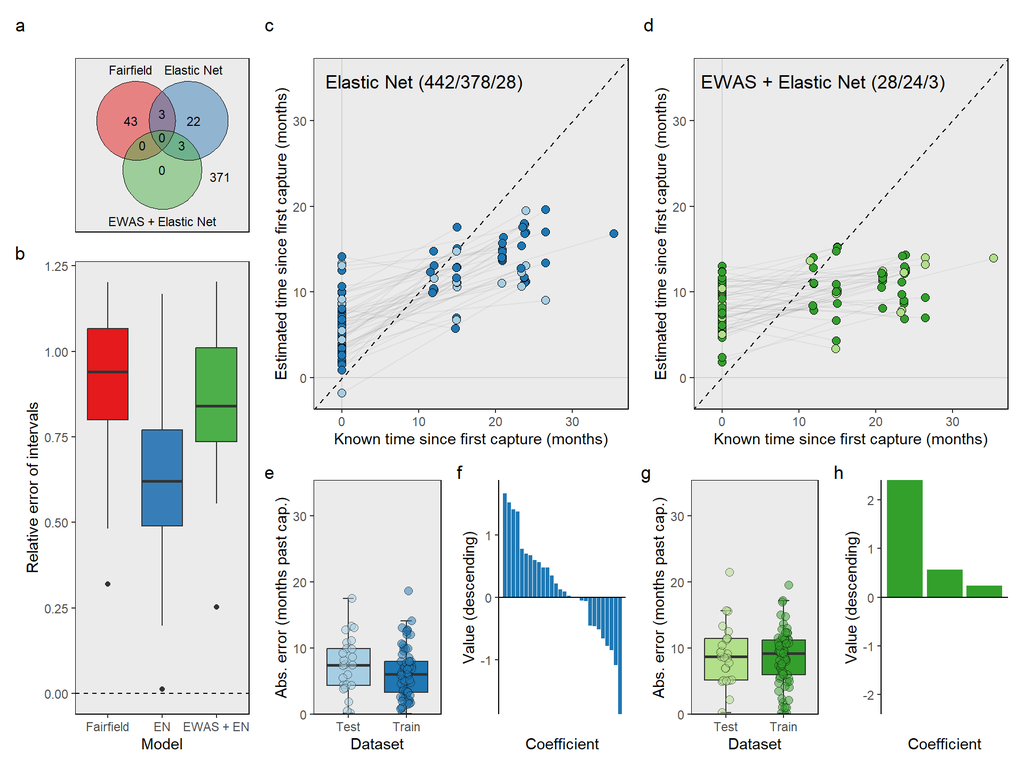

```r
# Top right (main)
plot_all_loci_predicted_vs_known_interval <- ageing_sample_estimates %>%
  dplyr::select(LobsterID, MonthsPassed, AllLociMonths, TestTrain) %>%
  tidyr::drop_na(AllLociMonths) %>%
  ggplot2::ggplot(
    ggplot2::aes(
      x = MonthsPassed,
      y = AllLociMonths,
      fill = TestTrain
    )
  ) +
  # Coordinate system
  ggplot2::geom_abline(slope = 1, intercept = 0, lty = 2, lwd = 0.5) +
  ggplot2::geom_vline(xintercept = 0, lty = 1, lwd = 0.5, alpha = 0.1) +
  ggplot2::geom_hline(yintercept = 0, lty = 1, lwd = 0.5, alpha = 0.1) +
  ggplot2::xlab("Known time since first capture (months)") +
  ggplot2::ylab("Estimated time since first capture (months)") +
  ggplot2::ylim(
    min(
      ageing_sample_estimates$AllLociMonths,
      ageing_sample_estimates$MonthsPassed,
      na.rm = TRUE
    ),
    max(
      ageing_sample_estimates$AllLociMonths,
      ageing_sample_estimates$MonthsPassed,
      na.rm = TRUE
    )
  ) +
  ggplot2::xlim(
    min(
      ageing_sample_estimates$AllLociMonths,
      ageing_sample_estimates$MonthsPassed,
      na.rm = TRUE
    ),
    max(
      ageing_sample_estimates$AllLociMonths,
      ageing_sample_estimates$MonthsPassed,
      na.rm = TRUE
    )
  ) +
  # Lines between points
  ggplot2::geom_line(
    ggplot2::aes(
      group = LobsterID
    ),
    col = LINE_COLOUR,
    alpha = LINE_ALPHA
  ) +
  # Points on top
  ggplot2::geom_point(pch = 21, size = POINT_SIZE, show.legend = FALSE) +
  ggplot2::scale_fill_manual(values = MODEL_TEST_TRAIN_COLOURS[1:2]) +
  ggplot2::ggtitle(
    paste0(
      "Elastic Net (",
      all_loci_regression$`Total available CpGs`, "/",
      all_loci_regression$`Total available post-filtering CpGs`, "/",
      nrow(all_loci_regression$`Non-zero coefficients`),
      ")"
    )
  ) +
  ggplot2::theme(plot.title = element_text(vjust = -10, hjust = 0.1)) +
  ggtheme_scatter

plot_ewas_loci_predicted_vs_known_interval <- ageing_sample_estimates %>%
  dplyr::select(LobsterID, MonthsPassed, EWASLociMonths, TestTrain) %>%
  tidyr::drop_na(EWASLociMonths) %>%
  ggplot2::ggplot(
    ggplot2::aes(
      x = MonthsPassed,
      y = EWASLociMonths,
      fill = TestTrain
    )
  ) +
  # Coordinate system
  ggplot2::geom_abline(slope = 1, intercept = 0, lty = 2, lwd = 0.5) +
  ggplot2::geom_vline(xintercept = 0, lty = 1, lwd = 0.5, alpha = 0.1) +
  ggplot2::geom_hline(yintercept = 0, lty = 1, lwd = 0.5, alpha = 0.1) +
  ggplot2::xlab("Known time since first capture (months)") +
  ggplot2::ylab("Estimated time since first capture (months)") +
  ggplot2::ylim(
    min(
      ageing_sample_estimates$AllLociMonths,
      ageing_sample_estimates$MonthsPassed,
      na.rm = TRUE
    ),
    max(
      ageing_sample_estimates$AllLociMonths,
      ageing_sample_estimates$MonthsPassed,
      na.rm = TRUE
    )
  ) +
  ggplot2::xlim(
    min(
      ageing_sample_estimates$AllLociMonths,
      ageing_sample_estimates$MonthsPassed,
      na.rm = TRUE
    ),
    max(
      ageing_sample_estimates$AllLociMonths,
      ageing_sample_estimates$MonthsPassed,
      na.rm = TRUE
    )
  ) +
  # Lines between points
  ggplot2::geom_line(
    ggplot2::aes(
      group = LobsterID
    ),
    col = LINE_COLOUR,
    alpha = LINE_ALPHA
  ) +
  # Points on top
  ggplot2::geom_point(pch = 21, size = POINT_SIZE, show.legend = FALSE) +
  ggplot2::scale_fill_manual(values = MODEL_TEST_TRAIN_COLOURS[3:4]) +
  ggplot2::ggtitle(
    paste0(
      "EWAS + Elastic Net (",
      ewas_loci_regression$`Total available CpGs`, "/",
      ewas_loci_regression$`Total available post-filtering CpGs`, "/",
      nrow(ewas_loci_regression$`Non-zero coefficients`),
      ")"
    )
  ) +
  ggplot2::theme(plot.title = element_text(vjust = -10, hjust = 0.1)) +
  ggtheme_scatter

plot_all_loci_test_train_errors <- ageing_sample_estimates %>%
  ggplot2::ggplot(
    ggplot2::aes(
      x = TestTrain,
      y = abs(AllLociMonths - MonthsPassed),
      fill = TestTrain
    )
  ) +
  ggplot2::ylab("Abs. error (months past cap.)") +
  ggplot2::xlab("Dataset") +
  ggplot2::geom_boxplot(
    staplewidth = 0.25,
    outliers = FALSE,
    show.legend = FALSE,
    fill = MODEL_TEST_TRAIN_COLOURS[1:2]
  ) +
  ggplot2::geom_point(
    pch = 21,
    alpha = 0.5,
    size = POINT_SIZE,
    show.legend = FALSE,
    position = ggplot2::position_jitter(width = 0.1)
  ) +
  ggplot2::scale_y_continuous(
    limits = c(0, max(ageing_sample_estimates$MonthsPassed)),
    expand = c(0,0)
  ) +
  ggplot2::scale_fill_manual(values = MODEL_TEST_TRAIN_COLOURS[1:2]) +
  ggtheme_scatter

plot_ewas_loci_test_train_errors <- ageing_sample_estimates %>%
  ggplot2::ggplot(
    ggplot2::aes(
      x = TestTrain,
      y = abs(EWASLociMonths - MonthsPassed),
      fill = TestTrain
    )
  ) +
  ggplot2::ylab("Abs. error (months past cap.)") +
  ggplot2::xlab("Dataset") +
  ggplot2::geom_boxplot(
    staplewidth = 0.25,
    outliers = FALSE,
    show.legend = FALSE,
    fill = MODEL_TEST_TRAIN_COLOURS[3:4]
  ) +
  ggplot2::geom_point(
    pch = 21,
    alpha = 0.5,
    size = POINT_SIZE,
    show.legend = FALSE,
    position = ggplot2::position_jitter(width = 0.1)
  ) +
  ggplot2::scale_y_continuous(
    limits = c(0, max(ageing_sample_estimates$MonthsPassed)),
    expand = c(0,0)
  ) +
  ggplot2::scale_fill_manual(values = MODEL_TEST_TRAIN_COLOURS[3:4]) +
  ggtheme_scatter

plot_all_loci_coefficients <- all_loci_regression$`Non-zero coefficients` %>%
  dplyr::rename(Value = s1) %>%
  dplyr::mutate(Coefficient = rownames(.)) %>%
  dplyr::arrange(desc(Value)) %>%
  dplyr::mutate(Coefficient = factor(Coefficient, levels = Coefficient)) %>%
  ggplot2::ggplot(
    aes(
      y = Value,
      x = Coefficient
    )
  ) +
  geom_col(fill = MODEL_TEST_TRAIN_COLOURS[2]) +
  geom_hline(yintercept = 0) +
  scale_y_continuous(expand = c(0, 0), limits = ggh4x::center_limits()) +
  scale_x_discrete(expand = c(0.05, 0.05)) +
  theme_classic() +
  theme(
    axis.line.x = element_blank(),
    axis.ticks.x = element_blank(),
    axis.text.x = element_blank()
  )

plot_ewas_loci_coefficients <- ewas_loci_regression$`Non-zero coefficients` %>%
  dplyr::rename(Value = s1) %>%
  dplyr::mutate(Coefficient = rownames(.)) %>%
  dplyr::arrange(desc(Value)) %>%
  dplyr::mutate(Coefficient = factor(Coefficient, levels = Coefficient)) %>%
  ggplot2::ggplot(
    aes(
      y = Value,
      x = Coefficient
    )
  ) +
  geom_col(fill = MODEL_TEST_TRAIN_COLOURS[4]) +
  geom_hline(yintercept = 0) +
  scale_y_continuous(expand = c(0, 0), limits = ggh4x::center_limits()) +
  scale_x_discrete(expand = c(0.2, 0.2)) +
  theme_classic() +
  theme(
    axis.line.x = element_blank(),
    axis.ticks.x = element_blank(),
    axis.text.x = element_blank()
  )

plot_model_comparison_figure <- (
  ( plot_venn_diagram / plot_model_comparison + xlab("Model") ) |
    (
      (
        plot_all_loci_predicted_vs_known_interval |
          plot_ewas_loci_predicted_vs_known_interval
      ) /
        (
          plot_all_loci_test_train_errors |
            plot_all_loci_coefficients + ylab("Value (descending)") |
            plot_ewas_loci_test_train_errors |
            plot_ewas_loci_coefficients + ylab("Value (descending)")
        )
    ) + plot_layout(heights = c(4.5, 3))
) + plot_layout(widths = c(2,8)) + plot_annotation(tag_levels = "a")
```

## Step 7: Revisit Fairfield data

I take the loci from my best updated model and see how well an epigenetic clock trained on them works for the Fairfield data.

### Load the Fairfield data

First, load their original dataset and format it similar to how I’ve formatted our own data in my earlier analyses (just for consistency and convenience):

```r
fairfield_lobster_methylation <- FAIRFIELD_DATA_PATH %>%
  readxl::read_xls() %>%
  dplyr::select(-`carapace size mm`, -`sex`, -`age description`) %>%
  dplyr::rename(LobsterID = `sample ID`) %>%
  dplyr::rename(KnownAgeMonths = `age_months`) %>%
  dplyr::rename_with(
    .cols = dplyr::starts_with("18S_"),
    .fn = ~ stringr::str_replace(.x, "18S", "CpG_18S_ITS1")
  ) %>%
  dplyr::rename_with(
    .cols = dplyr::starts_with("ITS1_"),
    .fn = ~ stringr::str_replace(.x, "ITS1", "CpG_18S_ITS1")
  ) %>%
  dplyr::rename_with(
    .cols = dplyr::starts_with("ITS2_"),
    .fn = ~ stringr::str_replace(.x, "ITS2", "CpG_ITS2_28S")
  ) %>%
  dplyr::rename_with(
    .cols = dplyr::starts_with("28S_"),
    .fn = ~ stringr::str_replace(.x, "28S", "CpG_ITS2_28S")
  )
```

Drop individuals with unknown age:

```r
fairfield_lobster_methylation %<>% tidyr::drop_na(KnownAgeMonths)
```

### Functionalising comparisons …

I make some functions to compare Fairfield et al.’s and our data with multiple combinations of loci …

#### Function to train a model

```r
run_regression_on_fairfield_data <- function(chosen_loci, model_name)
{
  train_versus_test_split <- fairfield_lobster_methylation %>%
    rsample::initial_split(strata = KnownAgeMonths)

  ids_responses_and_predictors_train <- rsample::training(train_versus_test_split)
  ids_responses_and_predictors_test <- rsample::testing(train_versus_test_split)

  responses_train <- ids_responses_and_predictors_train %>%
    dplyr::select(KnownAgeMonths)
  predictors_train <- ids_responses_and_predictors_train %>%
    dplyr::select(chosen_loci)
  responses_test <- ids_responses_and_predictors_test %>%
    dplyr::select(KnownAgeMonths)
  predictors_test <- ids_responses_and_predictors_test %>%
    dplyr::select(chosen_loci)

  # Only step that is different from earlier training: remember to convert to M!
  predictors_train %<>%
    apply(MARGIN = c(1, 2), FUN = convert_beta_to_m) %>%
    as.data.frame()
  predictors_test %<>%
    apply(MARGIN = c(1, 2), FUN = convert_beta_to_m) %>%
    as.data.frame()

  near_zero_variance_cpgs <- predictors_train %>%
    caret::nearZeroVar(names = TRUE)

  predictors_train %<>% dplyr::select(-near_zero_variance_cpgs)
  predictors_test %<>% dplyr::select(-near_zero_variance_cpgs)

  highly_correlated_cpgs <- predictors_train %>%
    stats::cor() %>%
    caret::findCorrelation(names = TRUE, exact = TRUE)

  predictors_train %<>% dplyr::select(-highly_correlated_cpgs)
  predictors_test %<>% dplyr::select(-highly_correlated_cpgs)

  # Make transformer for scaling/centering based on TRAINING DATA ONLY
  transformer_predictors_train <- caret::preProcess(predictors_train)

  # Scale and centre training and testing sets
  predictors_train %<>% stats::predict(object = transformer_predictors_train)
  predictors_test %<>% stats::predict(object = transformer_predictors_train)

  # Model training steps
  cross_validation_settings <- caret::trainControl(
    method = "repeatedcv",
    number = 10,
    repeats = 10
  )

  # Train model
  penalised_regression <- caret::train(
    x = as.matrix(predictors_train),
    y = unlist(responses_train),
    method = "glmnet",
    family = "gaussian",
    trControl = cross_validation_settings,
    tuneGrid = expand.grid(
      alpha = 0.5,
      lambda = 10 ^ seq(from = -3, to = 3, length.out = 100)
    )
  )

  coefficients <- coef(
    penalised_regression$finalModel,
    s = penalised_regression$bestTune[["lambda"]]
  )

  non_zero_coefficients <- coefficients %>%
    as.matrix() %>%
    as.data.frame() %>%
    dplyr::filter(s1 != 0) %>%
    slice(-1) # Minus the intercept!

  # (CpG AVAILABLE / AFTER FILTERING / RETAINED AFTER MODEL TRAINING)
  regression_plot_title <- paste0(
    model_name, " (",
    length(chosen_loci),
    "/",
    length(chosen_loci) - length(near_zero_variance_cpgs) - length(highly_correlated_cpgs),
    "/",
    nrow(non_zero_coefficients),
    ")"
  )

  regression_plot <- tidyr::tibble(
    `Estimated age (months)` = predict(penalised_regression),
    `Known age (months)` = unlist(responses_train$KnownAgeMonths)
  ) %>%
    ggplot2::ggplot(
      ggplot2::aes(
        x = `Known age (months)`,
        y = `Estimated age (months)`
      )
    ) +
    ggplot2::geom_smooth(method = "lm", colour = "black") +
    ggplot2::geom_point(aes(colour = "Training set"), size = 2) +
    ggplot2::geom_point(
      data = data.frame(
        TestAgeEstimates = predict(penalised_regression, predictors_test),
        TestAgeActual = unlist(responses_test$KnownAgeMonths)
      ),
      mapping = ggplot2::aes(
        colour = "Test set",
        x = TestAgeActual,
        y = TestAgeEstimates
      ),
      size = 0.75,
    ) +
    scale_colour_manual(
      values = c(
        `Training set` = "olivedrab3",
        `Test set` = "black"
      )
    ) +
    ggplot2::ggtitle(regression_plot_title) +
    ggplot2::theme(
      legend.background = element_rect(fill = NA, colour = NA),
      legend.key = element_rect(fill = NA, colour = NA),
      legend.position = "inside",
      legend.position.inside = c(0.25, 0.9),
      legend.title = element_blank(),
      plot.title = ggplot2::element_text(
        vjust = -5,
        hjust = 0.5,
        size = 12,
        margin = ggplot2::margin(t = -5)
      )
    ) +
    ggtheme_scatter

  coefficient_inset_plot <- non_zero_coefficients %>%
  dplyr::rename(Value = s1) %>%
  dplyr::mutate(Coefficient = rownames(.)) %>%
  dplyr::arrange(desc(Value)) %>%
  dplyr::mutate(Coefficient = factor(Coefficient, levels = Coefficient)) %>%
  ggplot2::ggplot(
    aes(
      y = Value,
      x = Coefficient
    )
  ) +
  geom_col() +
  geom_hline(yintercept = 0) +
  scale_y_continuous(expand = c(0, 0), limits = ggh4x::center_limits()) +
  scale_x_discrete(name = "Coeff.", expand = c(0.1, 0.1)) +
  theme_classic() +
  theme(
    axis.line.x = element_blank(),
    axis.ticks.x = element_blank(),
    axis.text.x = element_blank(),
    plot.background = element_rect(fill = NA, colour = NA),
    panel.background = element_rect(fill = NA, colour = NA)
  )

  combined_regression_plot <- regression_plot +
    inset_element(
      coefficient_inset_plot,
      left = 0.5, right = 1, top = 0.5, bottom = 0
    )

  return(
    list(
      `Regression` = penalised_regression,
      `Coefficients` = coefficients,
      `Non-zero coefficients` = non_zero_coefficients,
      `Plot` = combined_regression_plot,
      `Metrics` = as.data.frame(penalised_regression$bestTune) %>%
        dplyr::left_join(
          as.data.frame(penalised_regression$results),
          by = c("alpha", "lambda")
        )
    )
  )
}
```

#### Combined PCA functions

I can run a PCA on both Fairfield et al.’s original data and ours, to see if there is some clear trend with age and time between recaptures - they, after all, have known age samples. I functionalise these steps so I can try different locus combinations.

First, a function to combine the methylation datasets and remove any columns with values that will conflict with the PCA. Also convert to M values:

```r
combine_datasets_at_chosen_loci <- function(chosen_loci) {
  # I use the beta values from our data here so I can convert everything below
  combined_lobster_samples_and_beta_values <- lobster_samples %>%
    dplyr::select(LobsterID, SampleNumber, Encounter) %>%
    dplyr::left_join(sample_methylation) %>%
    dplyr::bind_rows(fairfield_lobster_methylation) %>%
    dplyr::relocate(KnownAgeMonths, .after = Encounter) %>%
    dplyr::select(
      LobsterID,
      SampleNumber,
      Encounter,
      KnownAgeMonths,
      tidyselect::where(~ ! any(is.na(.x)))
    )

  # Retain the loci that were used for the re-trained model on Fairfield's data
  combined_methylation_mvalues <- combined_lobster_samples_and_beta_values %>%
    dplyr::select(tidyselect::contains("CpG")) %>%
    apply(MARGIN = c(1, 2), FUN = convert_beta_to_m) %>%
    as.data.frame() %>%
    dplyr::select(tidyselect::all_of(chosen_loci))

  # Remove any columns with NA variances (near-zero numeric errors)
  combined_methylation_mvalues %<>%
    sapply(var) %>% is.na() %>% which() %>% names() %>%
    {
      dplyr::select(
        -tidyselect::all_of(.),
        .data = combined_methylation_mvalues
      )
    }

  return(
    list(
      `Combined sample data` = combined_lobster_samples_and_beta_values,
      `Combined M-values` = combined_methylation_mvalues
    )
  )
}
```

Then a function to run the PCA itself and extract the necessary data:

```r
run_comparative_pca <- function(
    combined_methylation_mvalues,
    combined_lobster_samples_and_beta_values
)
{
  combined_methylation_mvalues_pca <- prcomp(combined_methylation_mvalues)

  comparison_pca_plot_data <- combined_lobster_samples_and_beta_values %>%
    dplyr::select(LobsterID, Encounter, KnownAgeMonths) %>%
    cbind(combined_methylation_mvalues_pca$x[,c("PC1", "PC2")])

  combined_pca_importances <- combined_methylation_mvalues_pca %>%
    summary() %>%
    magrittr::use_series("importance") %>%
    { .["Proportion of Variance", ] } %>%
    magrittr::multiply_by(100) %>%
    round(digits = 1)

  combined_pca_xlims <- c(
    comparison_pca_plot_data$PC1 %>% min(),
    comparison_pca_plot_data$PC1 %>% max()
  )

  return(
    list(
      `Plot data` = comparison_pca_plot_data,
      `Importances` = combined_pca_importances,
      `Plot X-limits` = combined_pca_xlims
    )
  )
}
```

Finally, a function to plot the results:

```r
make_combined_pca_plot <- function(
    comparison_pca_plot_data,
    combined_pca_importances,
    combined_pca_xlims,
    number_of_loci_in_pca
)
{
  plot_comparison_pca <- comparison_pca_plot_data %>%
    tidyr::pivot_wider(
      values_from = c("PC1", "PC2"),
      names_from = c("Encounter")
    ) %>%
    dplyr::mutate(PC1_Capture = ifelse(is.na(PC1_Capture), PC1_NA, PC1_Capture)) %>%
    dplyr::mutate(PC2_Capture = ifelse(is.na(PC2_Capture), PC2_NA, PC2_Capture)) %>%
    dplyr::select(-PC1_NA, -PC2_NA) %>%
    ggplot2::ggplot(
      ggplot2::aes(
        x = PC1_Capture,
        xend = PC1_Recapture,
        y = PC2_Capture,
        yend = PC2_Recapture,
        fill = KnownAgeMonths,
        colour = PC1_Recapture - PC1_Capture
      )
    ) +
    ggplot2::xlab(
      paste0(
        "PC1 (",
        combined_pca_importances["PC1"],
        " %) of N = ",
        number_of_loci_in_pca,
        " CpGs"
      )
    ) +
    ggplot2::ylab(paste0("PC2 (", combined_pca_importances["PC2"], " %)")) +
    ggplot2::geom_segment(
      ggplot2::aes(group = LobsterID),
      arrow = grid::arrow(type = "closed", length = unit(0.25, "lines")),
      lwd = 1.25
    ) +
    ggplot2::geom_point(
      ggplot2::aes(alpha = !is.na(KnownAgeMonths) | is.na(PC1_Recapture)),
      pch = 21,
      size = 2.5,
      colour = "black"
    ) +
    ggplot2::guides(
      alpha = ggplot2::guide_none(),
      fill = ggplot2::guide_colourbar(
        order = 1,
        title = "Age (months)",
        display = "raster",
        ticks.colour = NA,
        frame.colour = "black",
        frame.linewidth = 0.25,
        title.position = "left",
        title.theme = ggplot2::element_text(angle = 90, hjust = 0.5)
      ),
      colour = ggplot2::guide_colourbar(
        order = 2,
        title = expression(Delta*" PC1"),
        display = "raster",
        ticks.colour = NA,
        frame.colour = "black",
        frame.linewidth = 0.25,
        title.position = "left",
        title.theme = ggplot2::element_text(angle = 90, hjust = 0.5),
        barheight = 4.4
      )
    ) +
    ggplot2::scale_x_continuous(limits = combined_pca_xlims, position = "top") +
    ggplot2::scale_alpha_manual(values = c(0, 1)) +
    ggplot2::scale_fill_distiller(palette = "OrRd") +
    ggplot2::scale_colour_distiller(
      palette = "BrBG",
      type = "div",
      limits = ggh4x::center_limits()
    ) +
    ggplot2::theme(
      panel.grid = ggplot2::element_blank(),
      panel.border = ggplot2::element_rect(fill = NA, colour = "black"),
      legend.background = ggplot2::element_rect(
        colour = "black",
        fill = "#ebebeb",
        linewidth = 0.25
      )
    )

  plot_pca_comparison_boxplot <- comparison_pca_plot_data %>%
    tidyr::drop_na(Encounter) %>%
    ggplot2::ggplot(
      ggplot2::aes(
        x = PC1,
        y = Encounter,
        fill = Encounter
      )
    ) +
    ggplot2::scale_fill_manual(values = c(CAP_COLOUR, RECAP_COLOUR)) +
    ggplot2::scale_x_continuous(limits = combined_pca_xlims) +
    ggplot2::scale_y_discrete(labels = c("Cap.", "Rec.")) +
    ggplot2::geom_boxplot(lwd = 0.25, show.legend = FALSE) +
    ggsignif::geom_signif(
      test = "t.test",
      test.args = list("paired" = TRUE),
      map_signif_level = TRUE,
      comparisons = list(c("Capture", "Recapture"))
    ) +
    ggplot2::theme_void() +
    ggplot2::theme(
      axis.text.y = ggplot2::element_text(size = 9)
    )

  # Output results of paired t test (implemented with lmer)
  comparison_pca_plot_data %>%
    lmerTest::lmer(
      data = .,
      PC1 ~ Encounter + (1 | LobsterID)
    ) %>%
    summary() %>%
    print()

  plot_comparison_pca <- (
    plot_comparison_pca /
      (
        plot_pca_comparison_boxplot + patchwork::plot_layout(tag_level = "new")
      ) +
      patchwork::plot_layout(heights = c(3.5, 0.5))
  )

  return(plot_comparison_pca)
}
```

### Comparisons with Fairfield data

Now I run this pipeline across three sets of loci, outputting some stats as we go:

```r
CHOSEN_LOCUS_SETS <- list(
  `Fairfield CpGs` = names(FAIRFIELD_ELASTICNET_CpG),
  `Elastic Net CpGs` = rownames(all_loci_regression$`Non-zero coefficients`),
  `EWAS CpGs` = ewas_significant_loci
)

all_plots <- NULL

for (locus_set_name in names(CHOSEN_LOCUS_SETS))
{
  chosen_loci_in_fairfield_data <- CHOSEN_LOCUS_SETS[[locus_set_name]] %>%
    magrittr::is_in(colnames(fairfield_lobster_methylation)) %>%
    subset(CHOSEN_LOCUS_SETS[[locus_set_name]], .)

  regression_objects <- run_regression_on_fairfield_data(
    chosen_loci = chosen_loci_in_fairfield_data,
    model_name = locus_set_name
  )

  # Output
  print(locus_set_name)
  print(regression_objects$Regression$bestTune)
  print(regression_objects$Metrics)

  regression_plot <- regression_objects$`Plot`
  regression_nonzero_cpgs <- rownames(regression_objects$`Non-zero coefficients`)

  data_objects <- combine_datasets_at_chosen_loci(regression_nonzero_cpgs)
  pca_objects <- run_comparative_pca(
    combined_methylation_mvalues = data_objects$`Combined M-values`,
    combined_lobster_samples_and_beta_values = data_objects$`Combined sample data`
  )
  pca_plot <- make_combined_pca_plot(
    combined_pca_xlims = pca_objects$`Plot X-limits`,
    combined_pca_importances = pca_objects$Importances,
    comparison_pca_plot_data = pca_objects$`Plot data`,
    number_of_loci_in_pca = length(regression_nonzero_cpgs)
  )

  all_plots <- all_plots /
    ((regression_plot | pca_plot) + patchwork::plot_layout(widths = c(3, 7)))
}
```

```
## [1] "Fairfield CpGs"
##    alpha   lambda
## 40   0.5 0.231013
##   alpha   lambda     RMSE  Rsquared      MAE    RMSESD RsquaredSD     MAESD
## 1   0.5 0.231013 3.563099 0.9618863 2.826684 0.6385033 0.01731351 0.5646672
## Linear mixed model fit by REML. t-tests use Satterthwaite's method [
## lmerModLmerTest]
## Formula: PC1 ~ Encounter + (1 | LobsterID)
##    Data: .
##
## REML criterion at convergence: 116.8
##
## Scaled residuals:
##     Min      1Q  Median      3Q     Max
## -2.8492 -0.6593  0.1635  0.6689  1.7804
##
## Random effects:
##  Groups    Name        Variance Std.Dev.
##  LobsterID (Intercept) 0.009375 0.09682
##  Residual              0.177720 0.42157
## Number of obs: 96, groups:  LobsterID, 48
##
## Fixed effects:
##                     Estimate Std. Error        df t value Pr(>|t|)
## (Intercept)        -2.252015   0.062432 93.764596 -36.071   <2e-16 ***
## EncounterRecapture -0.001058   0.086052 46.999989  -0.012     0.99
## ---
## Signif. codes:  0 '***' 0.001 '**' 0.01 '*' 0.05 '.' 0.1 ' ' 1
##
## Correlation of Fixed Effects:
##             (Intr)
## EncntrRcptr -0.689
## [1] "Elastic Net CpGs"
##    alpha    lambda
## 41   0.5 0.2656088
##   alpha    lambda     RMSE  Rsquared      MAE    RMSESD RsquaredSD     MAESD
## 1   0.5 0.2656088 5.504061 0.8897277 4.498124 0.9335722 0.05188948 0.8253925
## Linear mixed model fit by REML. t-tests use Satterthwaite's method [
## lmerModLmerTest]
## Formula: PC1 ~ Encounter + (1 | LobsterID)
```

[output cut: 41 more lines]

```
##  Groups    Name        Variance Std.Dev.
##  LobsterID (Intercept) 0.01688  0.1299
##  Residual              0.02466  0.1570
## Number of obs: 96, groups:  LobsterID, 48
##
## Fixed effects:
##                    Estimate Std. Error       df t value Pr(>|t|)
## (Intercept)        -0.66079    0.02942 80.67877 -22.463  < 2e-16 ***
## EncounterRecapture -0.12335    0.03205 47.00000  -3.848 0.000358 ***
## ---
## Signif. codes:  0 '***' 0.001 '**' 0.01 '*' 0.05 '.' 0.1 ' ' 1
##
## Correlation of Fixed Effects:
##             (Intr)
## EncntrRcptr -0.545
```

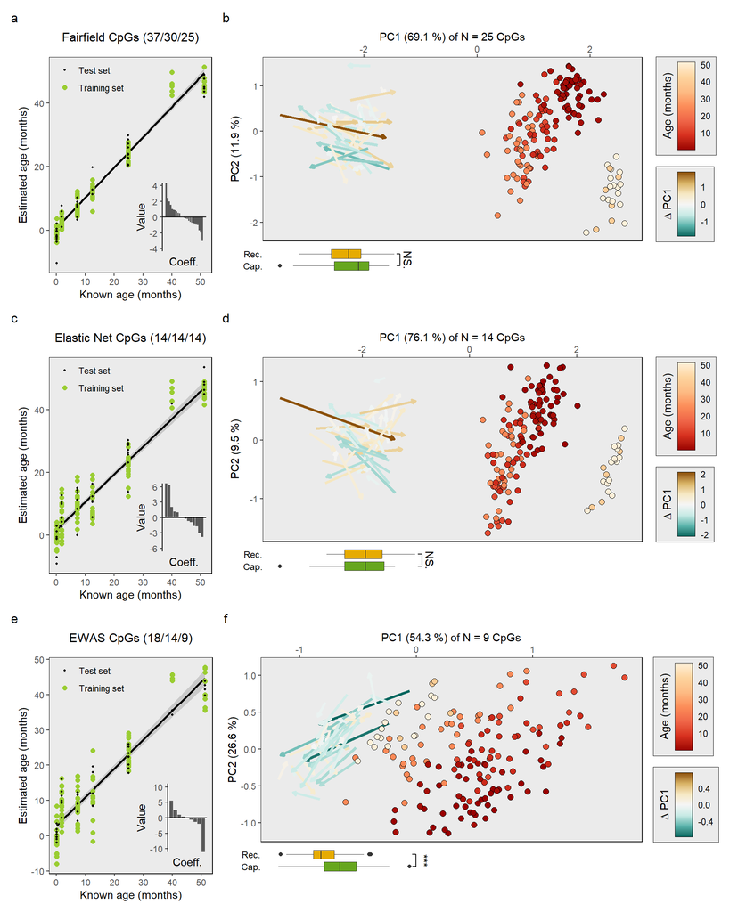

```r
plot_comparison_pca <- all_plots +
  plot_annotation(
    tag_levels = list(
      # Automatic tagging deals poorly with the insets, so define:
      c("a", "", "b", "c", "", "d", "e", "", "f")
    )
  )
```

END OF REPORT.